# Project Outline

```python
# load standard modules/libraries
import pandas as pd
import numpy as np
import matplotlib.pyplot as plt
import seaborn as sns
from sklearn.model_selection import train_test_split

# load special modules/libraries
import os
import warnings
import nltk
from nltk.corpus import stopwords
nltk.download('stopwords')

from collections import Counter
import string
import re
from tqdm  import tqdm
import copy


# load pytorch modules/libraries
import torch
import torch.nn as nn
import torch.nn.functional as F
import torch.optim as optim
from torch.utils.data import TensorDataset,DataLoader
```

# RNN Model

## 1. Data Cleaning

We will be using the "IMDB Movie Review Dataset" provided on the course website.

```python
# download IMDB review data

# load dataset
df = pd.read_csv("IMDB Dataset.csv")

# process into data and labels
X = df['review'].values
y = df['sentiment'].values
```

```python
# check the data type
print(f"Type of X: {type(X)}")
print(f"Type of y: {type(y)}")
```

```
Type of X: <class 'numpy.ndarray'>
Type of y: <class 'numpy.ndarray'>
```

```python
# check length of X and y
print(f"Number of reviews: {len(X)}")
print(f"Number of sentiments: {len(y)}")
print(f"Number of unique sentiments: {len(np.unique(y))}")
print(f"Unique sentiments: {np.unique(y)}")
```

```
Number of reviews: 50000
Number of sentiments: 50000
Number of unique sentiments: 2
Unique sentiments: ['negative' 'positive']
```

```python
# check how sentiments distributed among the two categories
print(f"Number of positive sentiments: {np.sum(y == 'positive')}")
print(f"Number of negative sentiments: {np.sum(y == 'negative')}")
```

```
Number of positive sentiments: 25000
Number of negative sentiments: 25000
```

```python
# randomly take a look at some of the positive reviews
for i in range(0,3):
  random_index = np.random.choice(np.where(y == 'positive')[0],1,replace=False)[0]
  print(f"Sentiment: {y[random_index]}")
  print(f"Number of word in this review: {len(X[random_index])}")
  print(f"Review: {X[random_index]}")
```

```
Sentiment: positive
Number of word in this review: 1604
Review: If you love the book, as I do, stop watching the video after Jean and Joe meet in Australia. Up to that point it is a fairly faithful rendition of the book, and the visuals are great. 10 out of 10 to that point and I've enjoyed it many times. After that, the story is seriously rearranged and…
Sentiment: positive
Number of word in this review: 2396
Review: The story is somewhat stilted, what with the main character's sudden reversals of fortune, but Leslie Howard and Bette Davis's portrayals of Philip Carey, the naïve obsessed lover and Mildred Rogers, the unworthy object of his affections, raise this film considerably above standard melodrama…
Sentiment: positive
Number of word in this review: 954
Review: 2 WORDS: Academy Award. Nuff said. This film had everything in it. Comedy to make me laugh, Drama to make me cry and one of the greatest dance scenes to rival Breakin 2: Electric Boogaloo. The acting was tip top of any independant film. Jeremy Earl was in top form long since seen since his s…
```

```python
# randomly take a look at some of the negative reviews
for i in range(0,3):
  random_index = np.random.choice(np.where(y == 'negative')[0],1,replace=False)[0]
  print(f"Sentiment: {y[random_index]}")
  print(f"Number of word in this review: {len(X[random_index])}")
  print(f"Review: {X[random_index]}")
```

```
Sentiment: negative
Number of word in this review: 947
Review: If this movie should be renamed, it should be "The Jackasses of Hazzard." To sum it up, this movie is nothing but 88 minutes of two immature country punks joyriding the famed 1968 Dodge Charger around town and in the country, chasing the girls and eluding the law.<br /><br />I have been a fa…
Sentiment: negative
Number of word in this review: 1988
Review: For a while when I was in-between jobs I had a habit of watching all the late night talk shows. For a while I had a good selection: Conan, Leno, Letterman, Ferguson, Kimmel...<br /><br />Until I reached the 1:30 a.m. time slot. The time between Conan and X- Files, on SciFi. And the only show…
Sentiment: negative
Number of word in this review: 1316
Review: I felt obliged to watch this movie all the way through, since I had found it in a bargain bin and bought it for my own, but I came close many times to turning it off and just writing off the money I had paid for it. If you are a fan of gore and sadism, this movie is OK. If there is one thing…
```

**Quality of data:**

1. The dataset contains 50,000 reviews with corresponding sentiments.
2. There are two unique sentiments: 'positive' and 'negative', each distributed equally with 25,000 instances.
3. Reviews and sentiments are stored as numpy arrays, which is efficient for numerical operations and indexing.
4. The dataset is balanced, with an equal number of positive and negative reviews (25000 each), which is good for training classification models without introducing bias.

**Potential challenges:**

1. As shown, reviews vary in length. This variation could be a challenge for some ML models that require consistent length uinput. Text pre-processing techniques such as padding or truncation may be needed when preparing the data.
2. The presence of HTML tags and special characters within the review texts can introduce noise into the dataset, potentially complicating the training of machine learning models.
3. Grammar and spelling errors within the reviews can lead to difficulties in accurately training machine learning models.
4. The sheer volume of the dataset, coupled with the extensive length of individual reviews, presents a computational challenge.

```python
# average length calculation
length_review = np.array([len(review) for review in X])
avg_length = np.mean(length_review)
print(f"Average character length of review: {avg_length}")

# length of longest review
print(f"Length of longest review: {np.max(length_review)}")

# length of shortest review
print(f"Length of shortest review: {np.min(length_review)}")
```

```
Average character length of review: 1309.43102
Length of longest review: 13704
Length of shortest review: 32
```

```python
# Number of positive and negative reviews
print(f"Number of positive reviews: {np.sum(y == 'positive')}")
print(f"Number of negative reviews: {np.sum(y == 'negative')}")

# average of positive review length
pos_length = length_review[y == "positive"]
avg_positive = np.mean(pos_length)
print(f"Average length of positive reviews: {avg_positive}")

# average of negative review length
neg_length = length_review[y == "negative"]
avg_negative = np.mean(neg_length)
print(f"Average length of negative reviews: {avg_negative}")
```

```
Number of positive reviews: 25000
Number of negative reviews: 25000
Average length of positive reviews: 1324.79768
Average length of negative reviews: 1294.06436
```

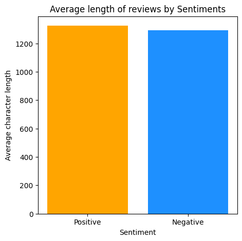

```python
# plot average length comparison
plt.figure(figsize=(5,5))
averages = [avg_positive, avg_negative]
sentiments = ['Positive', 'Negative']
plt.bar(sentiments, averages, color=['orange', 'dodgerblue'])
plt.xlabel("Sentiment")
plt.ylabel("Average character length")
plt.title("Average length of reviews by Sentiments")
plt.show()
```

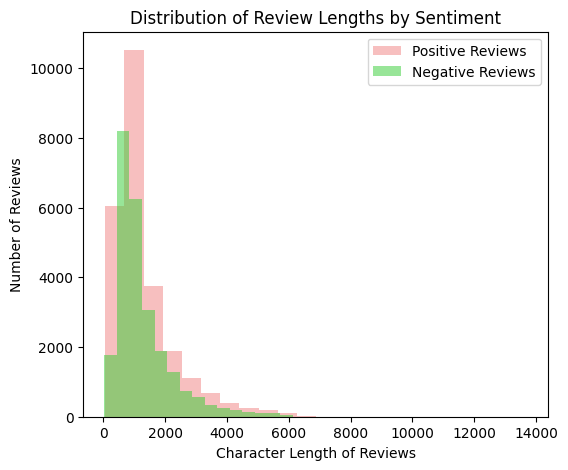

```python
# plot distribution of review length by sentiments
plt.figure(figsize=(6,5))
plt.hist(pos_length, bins=22, alpha=0.5, label="Positive Reviews", color= 'lightcoral')
plt.hist(neg_length, bins=22, alpha=0.5, label="Negative Reviews", color = 'limegreen')
plt.xlabel("Character Length of Reviews")
plt.ylabel("Number of Reviews")
plt.title("Distribution of Review Lengths by Sentiment")
plt.legend(loc='upper right')
plt.show()
```

**General observations:**

- The average character count per review is 1,309, indicating a tendency for moderately detailed reviews, potentially offering ample information for analyzing sentiments.
- The dataset is evenly distributed between positive and negative sentiments, with 25,000 instances of each. Such balance is crucial for training unbiased machine learning models.

**Observations positive vs negative:**

- The review lengths exhibit a right-skewed distribution, with a predominance of shorter reviews alongside a smaller number of much lengthier ones.
- Positive reviews tend to be marginally longer than negative ones, which may reflect a difference in how users express favorable versus unfavorable feedback.
- LSTMs might need fine-tuning to process the slightly longer positive reviews without losing key information at the end, a typical issue known as vanishing gradients.
- The majority of reviews being shorter suggests padding will be necessary to standardize input lengths. Incorrect padding could hinder learning, which can be mitigated by masking padded areas during training.
- LSTMs' risk of overfitting due to their complex architecture might be heightened by the varying lengths of reviews, calling for regularization strategies to avoid bias towards certain lengths or non-sentiment-related patterns.
- Long reviews will require more computational resources for LSTM training, affecting both the duration and cost of the model development process.

**Helper Code**

To process the data before training the LSTM model.

```python
X[0]
```

```
"One of the other reviewers has mentioned that after watching just 1 Oz episode you'll be hooked. They are right, as this is exactly what happened with me.<br /><br />The first thing that struck me about Oz was its brutality and unflinching scenes of violence, which set in right from the word GO. Tr…
```

```python
def preprocess_string(str1):
    # remove all non-word characters excluding number and letters
    str1= re.sub(r"[^\w\s]",'',str1)
    # remove all whitespace with no space
    str1= re.sub(r"\s",'',str1)
    # replace digits with no space
    str1= re.sub(r"\d",'',str1)
    return str1

def preprocess_sentence(sen1):
    word_list=[]
    stop_word = set(stopwords.words("english"))
    for word in sen1.lower().split():
        word = preprocess_string(word)
        if word not in stop_word and word!='':
            word_list.append(word)
    return word_list

def get_stoi(data):
    word_list=[]
    for review in data:
        word_list.extend(preprocess_sentence(review))
    corpus = Counter(word_list)
    print(corpus.get)
    # sorting on the basis of most common words
    corpus_ =sorted(corpus,key= corpus.get,reverse=True)[:1000]
    # creating a dict
    stoi =  {ch:i+1 for i,ch in enumerate(corpus_)}
    return stoi

def tokenize(data, labels, stoi):
    # tokenize
    data_encoded = []
    for review in data:
        data_encoded.append([stoi[word] for word in preprocess_sentence(review)
                                     if word in stoi.keys()])

    labels_encoded = [1 if label =='positive' else 0 for label in labels]

    return np.array(data_encoded, dtype=object), np.array(labels_encoded)


def padding_(sentences, seq_len):
    features = np.zeros((len(sentences), seq_len),dtype=int)
    for ii, review in enumerate(sentences):
        if len(review)!=0:
            features[ii, -len(review):] = np.array(review)[:seq_len]

    return features
```

The helper function will assist in pre-processing of the dataset, making it ready as our model's input:

- preprocess_string:

  It strips out punctuation, spaces, and numbers from text, which simplifies the data, so the model focuses on words that matter for sentiment.
- preprocess_sentence:

  Converts text to lowercase and removes common words that don't carry much sentiment, making sure we feed meaningful content to the model.
- get_stoi:

  Picks out the top 1,000 words used across all reviews and gives each a unique number. This keeps our model's size in check and speeds up training.
- tokenize:

  Converts reviews into lists of integers corresponding to words (excluding those not in the top 1,000) and turns sentiment labels into binary numerical values.
- padding_:

  Makes sure every review is the same length, which is a must for LSTM since it needs consistent input sizes batch-to-batch.

## 2. Splitting Data

Split the dataset into `train`, `valid`, and `test`. Use a 60-20-20 split. Then apply the above processing steps to prepare your data for training.

Set the padding of the reviews to 500.

```python
# split to 60-20-20
X_temp, X_test, y_temp, y_test = train_test_split(X, y, test_size=0.2, random_state=30)
X_train, X_val, y_train, y_val = train_test_split(X_temp, y_temp, test_size=0.25, random_state=30)  # 0.25 * 0.8 = 0.2


# mapping of words
stoi = get_stoi(X_train)

# tokenize and pad data
X_train_encoded, y_train_encoded = tokenize(X_train, y_train, stoi)
X_val_encoded, y_val_encoded = tokenize(X_val, y_val, stoi)
X_test_encoded, y_test_encoded = tokenize(X_test, y_test, stoi)

X_train_padded = padding_(X_train_encoded, 500)
X_val_padded = padding_(X_val_encoded, 500)
X_test_padded = padding_(X_test_encoded, 500)
```

```
<built-in method get of Counter object at 0x7d4030422b10>
```

```python
# take a look at the padded and encoded data
print(f"Shape of X_train_encoded: {X_train_encoded.shape}")
print(f"Shape of X_train_padded: {X_train_padded.shape}")

print("\nFirst entry in X_train_encoded:")
print(X_train_encoded[:1])

print("\nFirst entry in X_train_padded:")
print(X_train_padded[:1])
```

```
Shape of X_train_encoded: (30000,)
Shape of X_train_padded: (30000, 500)

First entry in X_train_encoded:
[list([104, 175, 245, 1, 303, 170, 28, 320, 12, 51, 84, 643, 462, 5, 206, 211, 613, 688, 243, 291, 175, 904, 250, 241, 1, 127, 14, 319, 10, 84, 367, 105, 217, 11, 6, 167, 1, 108, 71, 48, 349, 124, 213, 29, 229, 8, 39])]

First entry in X_train_padded:
[[  0   0   0   0   0   0   0   0   0   0   0   0   0   0   0   0   0   0
    0   0   0   0   0   0   0   0   0   0   0   0   0   0   0   0   0   0
    0   0   0   0   0   0   0   0   0   0   0   0   0   0   0   0   0   0
    0   0   0   0   0   0   0   0   0   0   0   0   0   0   0   0   0   0
    0   0   0   0   0   0   0   0   0   0   0   0   0   0   0   0   0   0
    0   0   0   0   0   0   0   0   0   0   0   0   0   0   0   0   0   0
    0   0   0   0   0   0   0   0   0   0   0   0   0   0   0   0   0   0
    0   0   0   0   0   0   0   0   0   0   0   0   0   0   0   0   0   0
```

[output cut: 20 more lines]

## 3. Data Loader

Create a DataLoader that will allow you to load the training and validation data in mini-batches. Then generate a dataset of batch size of 16 to verify that the DataLoader works as intended.

```python
# define ReviewDataset class
class ReviewDataset():
    def __init__(self, reviews, labels):
        self.reviews = reviews
        self.labels = labels

    def __len__(self):
        return len(self.reviews)

    def __getitem__(self, idx):
        review = self.reviews[idx]
        label = self.labels[idx]
        return {
            'review': torch.tensor(review, dtype=torch.long),
            'label': torch.tensor(label, dtype=torch.long)
        }

# Create dataset instances
train_dataset = ReviewDataset(X_train_padded, y_train_encoded)
val_dataset = ReviewDataset(X_val_padded, y_val_encoded)
test_dataset = ReviewDataset(X_test_padded, y_test_encoded)

# Create DataLoader instances
train_loader = DataLoader(train_dataset, batch_size=16, shuffle=True)
val_loader = DataLoader(val_dataset, batch_size=16, shuffle=False)
test_loader = DataLoader(test_dataset, batch_size=16, shuffle=False)

# example usage (1st batch)
for i, batch in enumerate(train_loader):
    print(f"Batch {i+1}")
    print(f"Reviews batch shape: {batch['review'].shape}")
    print(f"Label batch shape: {batch['label'].shape}")
    if i == 0:
        break
```

```
Batch 1
Reviews batch shape: torch.Size([16, 500])
Label batch shape: torch.Size([16])
```

## 4. Model Building

Build a recurrent neural network model, using at least one fully-connected layers to make the prediction based on your recurrent network output.

```python
# TO BE COMPLETED

class SentimentRNN(nn.Module):
    def __init__(self, vocab_size, output_size, embedding_dim, hidden_dim, n_layers, drop=0.5):
        super(SentimentRNN, self).__init__()
        self.name = "SentimentRNN"
        # parameter
        self.output_size = output_size
        self.n_layers = n_layers
        self.hidden_dim = hidden_dim
        # layers
        self.embedding = nn.Embedding(vocab_size, embedding_dim)
        self.rnn = nn.LSTM(embedding_dim, hidden_dim, n_layers, batch_first=True, dropout=drop)
        self.dropout = nn.Dropout(drop)
        self.fc = nn.Linear(2 * hidden_dim, output_size)
        self.sigmoid = nn.Sigmoid()


    def forward(self, x, hidden):
        batch_size = x.size(0)
        x = self.embedding(x)
        out, hidden = self.rnn(x, hidden)
        # max pooling and average pooling
        out_max = torch.max(out, dim=1)[0]
        out_avg = torch.mean(out, dim=1)
        out = torch.cat([out_max, out_avg], dim=1)
        out = self.dropout(out)
        out = self.fc(out)
        sig_out = self.sigmoid(out)
        final_out = sig_out.view(batch_size, -1)
        final_out = final_out[:,-1]

        return final_out, hidden

    def init_hidden(self, batch_size):
        # initialize hidden state
        weight = next(self.parameters()).data

        if (torch.cuda.is_available()):
          hidden = (weight.new(self.n_layers, batch_size, self.hidden_dim).zero_().cuda(),
                    weight.new(self.n_layers, batch_size, self.hidden_dim).zero_().cuda())
        else:
          hidden = (weight.new(self.n_layers, batch_size, self.hidden_dim).zero_(),
                    weight.new(self.n_layers, batch_size, self.hidden_dim).zero_())
        return hidden


# example usage
vocab_size = 1000
output_size = 1
embedding_dim = 500
hidden_dim = 128
n_layers = 2
model = SentimentRNN(vocab_size, output_size, embedding_dim, hidden_dim, n_layers)
```

## 5. Training

```python
def get_accuracy(model, data):
    """ Compute the accuracy of the `model` across a dataset `data`

    Example usage:

    >>> model = MyRNN() # to be defined
    >>> get_accuracy(model, valid_loader) # the variable `valid_loader` is from above
    """

    model.eval()
    total = 0
    correct = 0

    with torch.no_grad():
      for batch in data:
          input, label = batch['review'], batch['label']

          if torch.cuda.is_available():
            input, label = input.cuda(), label.cuda()

          output, _ = model(input, model.init_hidden(input.size(0)))
          prediction = output.round()
          total += label.size(0)
          correct += (prediction.squeeze() == label).sum().item()
    accuracy = correct / total
    model.train()

    return accuracy
```

```python
# training function
def train(model, train_loader, val_loader, num_epoch, learning_rate, batch_size, display=True):
    criterion = torch.nn.BCELoss()
    optimizer = torch.optim.Adam(model.parameters(), lr=learning_rate)

    best_val_accuracy = 0.0
    best_model_state = None
    print(f"Start Training...")
    print(f"Total epoch: {num_epoch}, lr: {learning_rate}, bs: {batch_size}")
    if torch.cuda.is_available():
        print("cuda is available, training on GPU...\n")

    train_losses = []
    train_accuracies = []
    val_accuracies = []

    for epoch in range(num_epoch):
        model.train()
        current_loss = 0.0
        correct_pred = 0
        total_pred = 0

        # training loop
        for batch in train_loader:
            input, label = batch['review'],batch['label']
            hidden = model.init_hidden(input.size(0))
            if torch.cuda.is_available():
                input, label = input.cuda(), label.cuda()
            hidden = tuple([each.data for each in hidden])
            optimizer.zero_grad()
            output, hidden = model(input, hidden)
            label = label.float()
            loss = criterion(output, label)
            loss.backward()
            optimizer.step()

            current_loss += loss.item()
        # calculate loss and accuracy
        avg_train_loss = current_loss / len(train_loader)
        train_losses.append(avg_train_loss)
        train_accuracy = get_accuracy(model, train_loader)
        val_accuracy = get_accuracy(model, val_loader)
        train_accuracies.append(train_accuracy)
        val_accuracies .append(val_accuracy)

        print(f"Epoch {epoch}/{num_epoch-1}, Training_loss: {avg_train_loss:.5f}")
        print(f"Training Accuracy: {train_accuracy: .5f}, Validation Accuracy: {val_accuracy: .5f}\n")

        # save best val_accuracy
        if val_accuracy > best_val_accuracy:
            best_val_accuracy = val_accuracy
            best_model_state = copy.deepcopy(model.state_dict())
            best_epoch = epoch

    # checkpoint - save best model
    if best_model_state is not None:
        model_path = "model_{0}_bs{1}_lr{2}_epoch{3}.pth".format(model.name, batch_size, learning_rate, best_epoch)
        torch.save(best_model_state, model_path)
        print(f"Best Model is saved at {model_path} with Validation Accuracy {best_val_accuracy}")

    # plotting
    if display is True:
        plt.figure(figsize=(12,4))

        # plotting training losses
        plt.subplot(1, 2, 1)
        plt.plot(train_losses, label='Training Loss')
        plt.xlabel('Epochs')
        plt.ylabel('Loss')
        plt.title('Training Loss')
        plt.xticks(range(0, num_epoch))
        plt.legend()

        # plotting training and validation accuracies
        plt.subplot(1, 2, 2)
        plt.plot(train_accuracies, label='Training Accuracy')
        plt.plot(val_accuracies, label='Validation Accuracy')
        plt.xlabel('Epochs')
        plt.ylabel('Accuracy')
        plt.title('Training and Validation Accuracy')
        plt.xticks(range(0, num_epoch))
        plt.legend()

        plt.show()
```

## 6. Hyperparameter Tuning

#### Model 1

Fixed hyperparameters:

- output_size = 1
- vocab_size = len(stoi) + 1

Tuned hyperparameters:

- Embedding_dim = 300
- hidden_dim = 128
- n_layers = 2
- drop = 0.5
- learning_rate = 0.001
- num_epoch = 8
- batch_size = 64

```
Start Training...
Total epoch: 8, lr: 0.001, bs: 64
cuda is available, training on GPU...

Training Accuracy:  0.86000, Validation Accuracy:  0.83110

Training Accuracy:  0.89240, Validation Accuracy:  0.84440

Training Accuracy:  0.91307, Validation Accuracy:  0.84330

Training Accuracy:  0.93757, Validation Accuracy:  0.84410

Training Accuracy:  0.96123, Validation Accuracy:  0.84320

Training Accuracy:  0.96953, Validation Accuracy:  0.84190

Training Accuracy:  0.98150, Validation Accuracy:  0.83700

Training Accuracy:  0.98360, Validation Accuracy:  0.83480

Best Model is saved at model_SentimentRNN_bs64_lr0.001_epoch1.pth with Validation Accuracy 0.8444
```

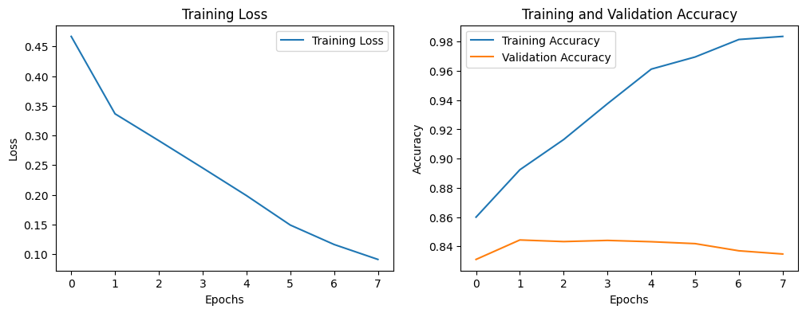

```python
# train Model 1
output_size = 1
vocab_size = len(stoi) + 1

embedding_dim = 300
hidden_dim = 128
n_layers = 2
drop = 0.5
learning_rate = 0.001
num_epoch = 8
batch_size = 64

train_loader = DataLoader(train_dataset, batch_size=batch_size, shuffle=True)
val_loader = DataLoader(val_dataset, batch_size=batch_size, shuffle=False)
test_loader = DataLoader(test_dataset, batch_size=batch_size, shuffle=False)

device = torch.device("cuda" if torch.cuda.is_available() else "cpu")
model1 = SentimentRNN(vocab_size, output_size, embedding_dim, hidden_dim, n_layers, drop)
model1 = model1.to(device)
train(model1, train_loader, val_loader, num_epoch, learning_rate, batch_size, display=True)
```

**Analysis**

SentimentRNN model was configured with a binary output size to differentiate between positive and negative sentiments. The model's vocabulary was defined by the unique index mapping of the dataset's words, expanded by one to account for padding. With an embedding dimension of 300, the model captures semantic details without excessive computational load. A hidden dimension of 128 and two LSTM layers allow the model to identify complex patterns while mitigating the risk of overfitting, which is further addressed by a substantial dropout rate of 0.5. The learning rate was set at a standard 0.001, with 8 epochs determined as the optimal number based on validation accuracy plateauing early, suggesting limited benefits from additional training.

#### Model 2

Fixed hyperparameters:

- output_size = 1
- vocab_size = len(stoi) + 1

Tuned hyperparameters:

- Embedding_dim = 200
- hidden_dim = 64
- n_layers = 3
- drop = 0.5
- learning_rate = 0.0007
- num_epoch = 8
- batch_size = 128

```
Start Training...
Total epoch: 8, lr: 0.0007, bs: 128
cuda is available, training on GPU...

Training Accuracy:  0.81033, Validation Accuracy:  0.79030

Training Accuracy:  0.85430, Validation Accuracy:  0.82650

Training Accuracy:  0.87737, Validation Accuracy:  0.83500

Training Accuracy:  0.89147, Validation Accuracy:  0.84070

Training Accuracy:  0.90390, Validation Accuracy:  0.84040

Training Accuracy:  0.91340, Validation Accuracy:  0.84190

Training Accuracy:  0.92177, Validation Accuracy:  0.83150

Training Accuracy:  0.93520, Validation Accuracy:  0.83800

Best Model is saved at model_SentimentRNN_bs128_lr0.0007_epoch5.pth with Validation Accuracy 0.8419
```

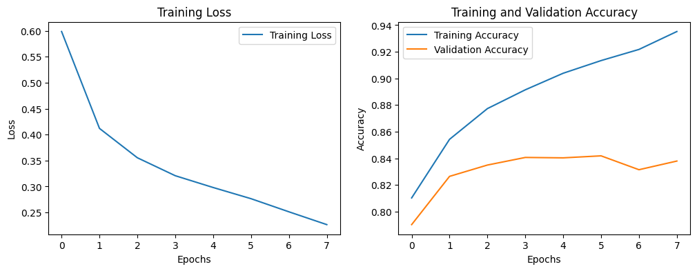

```python
# train Model 2
output_size = 1
vocab_size = len(stoi) + 1

embedding_dim = 200
hidden_dim = 64
n_layers = 3
drop = 0.5
learning_rate = 0.0007
num_epoch = 8
batch_size = 128

train_loader = DataLoader(train_dataset, batch_size=batch_size, shuffle=True)
val_loader = DataLoader(val_dataset, batch_size=batch_size, shuffle=False)
test_loader = DataLoader(test_dataset, batch_size=batch_size, shuffle=False)

model2 = SentimentRNN(vocab_size, output_size, embedding_dim, hidden_dim, n_layers, drop)
model2 = model2.to(device)
train(model2, train_loader, val_loader, num_epoch, learning_rate, batch_size, display=True)
```

**Analysis**

The network architecture was designed to differentiate between positive and negative sentiments with a binary output size. The model was trained on a vocabulary that was established from the dataset, with an additional token for padding. An embedding dimension of 200 was chosen, aiming to capture the essence of the word meanings while maintaining computational efficiency. The model featured a smaller hidden dimension of 64 and an increased number of layers, set to 3, intending to capture more nuanced patterns in the data. However, the smaller hidden units combined with more layers could potentially lead to more complex inter-layer dependencies. A dropout rate of 0.5 was again utilized to prevent overfitting, a common challenge in training RNNs. A slightly lower learning rate of 0.0007 and a larger batch size of 128 were used, suggesting an approach that prioritizes stability over swiftness in training updates. The model was trained for 8 epochs, a decision likely based on observing the point of diminishing returns in validation accuracy improvement.

#### Model 3

Fixed hyperparameters:

- output_size = 1
- vocab_size = len(stoi) + 1

Tuned hyperparameters:

- Embedding_dim = 128
- hidden_dim = 256
- n_layers = 2
- drop = 0.4
- learning_rate = 0.0005
- num_epoch = 8
- batch_size = 32

```
Start Training...
Total epoch: 8, lr: 0.0005, bs: 32
cuda is available, training on GPU...

Training Accuracy:  0.84117, Validation Accuracy:  0.81750

Training Accuracy:  0.87470, Validation Accuracy:  0.84030

Training Accuracy:  0.89600, Validation Accuracy:  0.85120

Training Accuracy:  0.91593, Validation Accuracy:  0.85510

Training Accuracy:  0.93153, Validation Accuracy:  0.85160

Training Accuracy:  0.94120, Validation Accuracy:  0.83790

Training Accuracy:  0.97750, Validation Accuracy:  0.84280

Training Accuracy:  0.98520, Validation Accuracy:  0.84060

Best Model is saved at model_SentimentRNN_bs32_lr0.0005_epoch3.pth with Validation Accuracy 0.8551
```

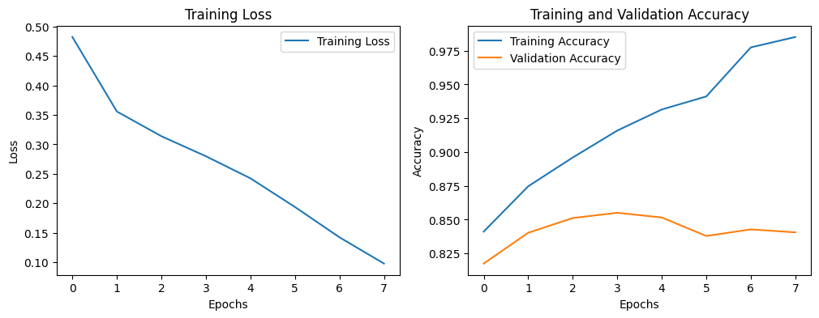

```python
# train Model 3
output_size = 1
vocab_size = len(stoi) + 1

embedding_dim = 128
hidden_dim = 256
n_layers = 2
drop = 0.4
learning_rate = 0.0005
num_epoch = 8
batch_size = 32

train_loader = DataLoader(train_dataset, batch_size=batch_size, shuffle=True)
val_loader = DataLoader(val_dataset, batch_size=batch_size, shuffle=False)
test_loader = DataLoader(test_dataset, batch_size=batch_size, shuffle=False)

model3 = SentimentRNN(vocab_size, output_size, embedding_dim, hidden_dim, n_layers, drop)
model3 = model3.to(device)
train(model3, train_loader, val_loader, num_epoch, learning_rate, batch_size, display=True)
```

**Analysis**

Model 3's architecture was designed to balance detailed learning with computational efficiency for sentiment analysis. The 128-dimensional word embeddings offer a compact yet expressive representation of the dataset's vocabulary, while a relatively large hidden dimension of 256 in the two-layer LSTM structure equips the model with the capability to discern complex data patterns. This increased learning capacity is regulated by a 0.4 dropout rate to mitigate overfitting. The learning process was cautiously paced with a learning rate of 0.0005 and conducted over 8 epochs, with a smaller batch size of 32 to promote gradient accuracy and model generalization.

The model demonstrated a promising learning curve, with training loss consistently decreasing and training accuracy ascending to a high in the final epoch. However, validation accuracy reached its zenith earlier in the third epoch at around 0.8551, suggesting the model's learning plateaued thereafter. This indicates that while the model was adept at fitting the training data, its generalization to validation data did not correspondingly improve, emphasizing the need for early stopping or further hyperparameter tuning to enhance model performance on new, unseen data.

#### Model 4

Fixed hyperparameters:

- output_size = 1
- vocab_size = len(stoi) + 1

Tuned hyperparameters:

- Embedding_dim = 64
- hidden_dim = 256
- n_layers = 2
- drop = 0.4
- learning_rate = 0.0003
- num_epoch = 8
- batch_size = 32

```
Start Training...
Total epoch: 8, lr: 0.0003, bs: 32
cuda is available, training on GPU...

Training Accuracy:  0.79910, Validation Accuracy:  0.78320

Training Accuracy:  0.83560, Validation Accuracy:  0.81080

Training Accuracy:  0.85127, Validation Accuracy:  0.82260

Training Accuracy:  0.87397, Validation Accuracy:  0.83890

Training Accuracy:  0.87383, Validation Accuracy:  0.83670

Training Accuracy:  0.89287, Validation Accuracy:  0.84070

Training Accuracy:  0.90507, Validation Accuracy:  0.84190

Training Accuracy:  0.91163, Validation Accuracy:  0.84180

Best Model is saved at model_SentimentRNN_bs32_lr0.0003_epoch6.pth with Validation Accuracy 0.8419
```

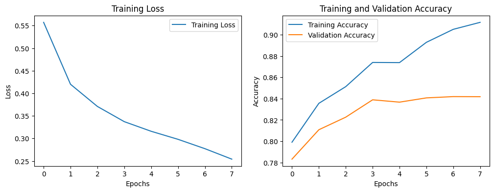

```python
# train Model 4
output_size = 1
vocab_size = len(stoi) + 1

embedding_dim = 64
hidden_dim = 256
n_layers = 2
drop = 0.4
learning_rate = 0.0003
num_epoch = 8
batch_size = 32

train_loader = DataLoader(train_dataset, batch_size=batch_size, shuffle=True)
val_loader = DataLoader(val_dataset, batch_size=batch_size, shuffle=False)
test_loader = DataLoader(test_dataset, batch_size=batch_size, shuffle=False)

model4 = SentimentRNN(vocab_size, output_size, embedding_dim, hidden_dim, n_layers, drop)
model4 = model4.to(device)
train(model4, train_loader, val_loader, num_epoch, learning_rate, batch_size, display=True)
```

**Analysis**

For Model 4, the chosen embedding dimension of 64, albeit lower than previous models, sought to encapsulate word meanings efficiently, potentially aiding faster computation. Meanwhile, a substantial hidden dimension of 256 allowed for the nuanced capture of sequential dependencies, set within a dual-layer LSTM framework. This was complemented by a 0.4 dropout rate to counter overfitting risks and a learning rate of 0.0003 to ensure steady progression through the optimization landscape. The training was distributed over 8 epochs, with a batch size of 32, to optimize the learning process without overextending computational resources.

## 7. Evaluation

```python
# accuracy on test dataset
output_size = 1
vocab_size = len(stoi) + 1

embedding_dim = 64
hidden_dim = 256
n_layers = 2
drop = 0.4
learning_rate = 0.0003
num_epoch = 8
batch_size = 32
best_model_path = 'model_SentimentRNN_bs32_lr0.0003_epoch6.pth'
best_model = SentimentRNN(vocab_size, output_size, embedding_dim, hidden_dim, n_layers, drop)
best_model = best_model.to(device)
state = torch.load(best_model_path)
best_model.load_state_dict(state)
best_model.eval()
test_accuracy = get_accuracy(best_model, test_loader)
print("Training Accuracy:  0.90507")
print("Validation Accuracy:  0.84190")
print(f"Test Accuracy: {test_accuracy:.5f}")
```

```
Training Accuracy:  0.90507
Validation Accuracy:  0.84190
Test Accuracy: 0.84710
```

**Analysis of the result**

The final test accuracy of the model stands at 0.84710, which is encouragingly consistent with the validation accuracy of 0.84190. This close correlation suggests that the model has generalized well, as it performs almost identically on new data as it did during the validation phase.

The model's training accuracy of 0.90507 is higher than both validation and test accuracies, which is a typical observation indicating that the model fits well to the training data. However, the fact that this discrepancy is not too large suggests that the model has not overfitted to the training set to a detrimental extent. It managed to maintain a commendable level of generalization.

These results are largely in line with what I expected. The use of regularization techniques such as dropout was intended to curb overfitting, and the close alignment between validation and test performance indicates success in this area. While there's always room for improvement—potentially by further hyperparameter tuning or experimenting with different architectures—the model has proven to be robust and reliable, which bodes well for its deployment in real-world applications where it needs to interpret and analyze sentiment accurately on data it has never seen before.

```python
# report misclassified
def get_misclassified(model, data_loader, stoi, itos):
    # stoi: dictionary mapping words to indices
    # itos: dictionary mapping indices to words (reverse of stoi)

    model.eval()
    misclassified = []

    with torch.no_grad():
        for batch in data_loader:
            input, label = batch['review'], batch['label']
            batch_size = input.size(0)
            hidden = model.init_hidden(batch_size)

            if torch.cuda.is_available():
                input, label = input.cuda(), label.cuda()

            output, hidden = model(input, hidden)
            predictions = output.round().squeeze()

            # Find indices where predictions and labels differ
            mismatches = predictions != label
            for idx in torch.where(mismatches)[0]:
                review = input[idx]
                true_label = label[idx].item()
                predicted_label = predictions[idx].item()
                # Convert input tokens to words
                review_text = ' '.join([itos[token.item()] for token in review if token.item() in itos])

                misclassified.append({
                    'review': review_text,
                    'true_label': 'positive' if true_label == 1 else 'negative',
                    'predicted_label': 'positive' if predicted_label == 1 else 'negative'
                })

    model.train()
    return misclassified
```

```python
# show 5 examples
itos = {i: word for word, i in stoi.items()}
misclassified_samples = get_misclassified(best_model, test_loader, stoi, itos)
for i, sample in enumerate(misclassified_samples[:5]):
    print(f"Misclassified Sample {i+1}:")
    print(f"Review: {sample['review']}")
    print(f"True Label: {sample['true_label']}")
    print(f"Predicted Label: {sample['predicted_label']}")
    print("-" * 50)
```

```
Misclassified Sample 1:
Review: finally watched episodes go back actually produced absolutely scary made fun would future either weird people pay attention things scary white house someone wait sort may seemed time must brilliant
True Label: positive
Predicted Label: negative
--------------------------------------------------
Misclassified Sample 2:
Review: reason say wrote screenplay knew little made see film wrote producers without telling friend got hear written first heard peter whether might like another also could see original script lost told late thing could took name idea might done screenplay see film quickly name put back made piece …
True Label: positive
Predicted Label: negative
--------------------------------------------------
Misclassified Sample 3:
Review: watch film horror heart mother also head like ive times find mother leave see act like made wonder time watched never bad want know worst scene watching old room never try looks like except know get
True Label: positive
Predicted Label: negative
--------------------------------------------------
Misclassified Sample 4:
Review: sorry dont much time write known one years said portrayed well agree also said robert portrayed person couldnt agree film seen films would top friend end film many people less one
True Label: positive
Predicted Label: negative
--------------------------------------------------
Misclassified Sample 5:
Review: kind genre thing either like dont youll love dancing bill james songs dance turn br film first song okay next three nothing story didnt much either another dont think ive seen movie liked including one english half movie leave br br however production lot many particularly liked sound music …
True Label: negative
Predicted Label: positive
--------------------------------------------------
```

**Analysis and Findings**

From the samples of misclassified reviews, I observed that some positive reviews were incorrectly labeled as negative, largely due to the prevalence of words with typically negative connotations, such as "horror," "scary," "sorry," and "less." These words often appeared in the context of describing movie content, which may not inherently reflect the reviewer's sentiment towards the movie but rather its thematic elements. This discrepancy highlights the model's challenge in distinguishing between content description and sentiment expression, especially when negative vocabulary overshadows the sparse positive indicators within the text.

```python
review = """ Man.... I wish I loved this movie more than I did. Don't get me wrong,
it's a solid action movie with jaw-dropping stunts (some of the best in the series),
but as a Mission: Impossible movie, it felt like a small step backward for the franchise.
Fallout had mind-blowing action sequences and stunt work, along with developing Ethan's
relationship with Ilsa, providing closure with Julia, showing the lengths Ethan would
go to protect those closest to him, and battling an imposing villain. Dead Reckoning:
Part One stretches the movie across two films only to seemingly showcase action
spectacle after action spectacle while sacrificing character development.
Characters I have grown to love over a decade of films felt sidelined, ignored,
or wasted. Hayley Atwell's new character chewed up most of the screen time, and
while she was fantastic, I wanted to see more of the original team. The new villain
had an inconsistent ability that confused more than intimidated. There were some
important emotional moments that I just didn't feel the weight of when I definitely
should have. Part Two might tie everything together and make me enjoy Part One
more in retrospect, but unfortunately, I left wanting more from this one. """
```

```python
# report probability of review being positive
preprocessed_review = preprocess_sentence(review)

# Tokenize the review using stoi, handling unknown words
tokenized_review = [stoi.get(word, 0) for word in preprocessed_review]

# Pad the tokenized review
padded_review = padding_([tokenized_review], 500)

# Convert padded_review to tensor and send to the same device as the model
input = torch.tensor(padded_review).to(device)

# Predict the sentiment
with torch.no_grad():
    batch_size = input.size(0)
    hidden = best_model.init_hidden(batch_size)
    hidden = tuple([each.data for each in hidden])
    output, hidden = best_model(input, hidden)
    predicted_probability = torch.sigmoid(output).item()  # Get the probability of being positive

print(f"Predicted probability of the review being positive: {predicted_probability:.4f}")
```

```
Predicted probability of the review being positive: 0.7075
```

It is a complex task to distinguish between positive and negative reviews because of linguistic nuances like sarcasm and colloquial idioms. It's best to start with basic baseline models before moving on to more complex ones, like RNNs, in order to manage this complexity. A straightforward approach to start is with a Keyword Counting Model, which measures sentiment indicators in reviews and establishes a baseline against which other comparisons can be made.

To improve on this first strategy, techniques such as the Naive Bayes Classifier and Bag-of-Words or TF-IDF score can be used to provide complexity without sacrificing ease of use. A strong baseline is established by the Naive Bayes Classifier, which is well-known for its word probability-based text classification abilities, in conjunction with the sophisticated text representation offered by TF-IDF and Bag-of-Words. This can be reinforced further using a basic neural network or Linear SVM, guaranteeing that our baseline models are both complete and easily understandable, enabling a more sophisticated comprehension of text representation.

A crucial step is moving from these more basic models to the complexity of RNNs. We may carefully weigh the trade-offs by comparing the performance of the basic models with the sophisticated capabilities of RNNs. This comparison is crucial because it shows whether the more sophisticated models, such as RNNs, with their higher complexity and resource requirements, are worth it for the more profound analytical insights and nuanced understanding they provide. This layered approach—from simple to sophisticated—ensures a comprehensive assessment of sentiment analysis models and emphasizes the significance of beginning with baselines that are both effective and easily interpreted.

# Bert Model

```python
# install relevant libraries
!pip install -qq transformers
```

```python
# load relevant libraries
import transformers
from transformers import BertModel, BertTokenizer, AdamW, get_linear_schedule_with_warmup

PRE_TRAINED_MODEL_NAME = 'bert-base-cased'

tokenizer = BertTokenizer.from_pretrained(PRE_TRAINED_MODEL_NAME)
bert_model = BertModel.from_pretrained(PRE_TRAINED_MODEL_NAME)

################### SUBMISSION NOTE ####################################
#  - output of this cell creates issues for converting ipynb to HTML
#  - you may want to delete this output when you are ready to submit
```

```python
sample_txt = 'I want to learn how to do sentiment analysis using BERT and tokenizer.'

encoding = tokenizer.encode_plus(
  sample_txt,
  max_length=32,
  add_special_tokens=True, # Add '[CLS]' and '[SEP]'
  return_token_type_ids=False,
  pad_to_max_length=True,
  return_attention_mask=True,
  return_tensors='pt',  # Return PyTorch tensors
  truncation = True
)
```

```python
encoding['input_ids']
```

```
tensor([[  101,   146,  1328,  1106,  3858,  1293,  1106,  1202, 17024,  3622,
          1606,   139,  9637,  1942,  1105, 22559, 17260,   119,   102,     0,
             0,     0,     0,     0,     0,     0,     0,     0,     0,     0,
             0,     0]])
```

```python
encoding['attention_mask']
```

```
tensor([[1, 1, 1, 1, 1, 1, 1, 1, 1, 1, 1, 1, 1, 1, 1, 1, 1, 1, 1, 0, 0, 0, 0, 0,
         0, 0, 0, 0, 0, 0, 0, 0]])
```

```python
hidden_states = bert_model(input_ids=encoding['input_ids'],
                           attention_mask=encoding['attention_mask'])[0]
pooled_output = bert_model(input_ids=encoding['input_ids'],
                           attention_mask=encoding['attention_mask'])[1]
```

```python
hidden_size = bert_model.config.hidden_size

print(hidden_size)
print(hidden_states.shape)
print(pooled_output.shape)
```

```
768
torch.Size([1, 32, 768])
torch.Size([1, 768])
```

In the sample code provided we loaded a short text sequence, tokenized it using the same tokenization that was used in the pretrained BERT model, and fed the tokenized input into the BERT model to obtain the embeddings.

Note that you can preprocess all of the data prior to training a classifier stage for sentiment analysis to help speed up the training process. This is no different from the process we applied in an earlier assignment using AlexNet and image data.

## 1. Data Loading

```python
from torch.utils.data import Dataset, DataLoader

class MovieReviewDataset(Dataset):

  def __init__(self, reviews, targets, tokenizer, max_len):
    self.reviews = reviews
    self.targets = targets
    self.tokenizer = tokenizer
    self.max_len = max_len

  def __len__(self):
    return len(self.reviews)

  def __getitem__(self, item):
    review = str(self.reviews[item])
    #obtain numerical labels
    target = 1 if self.targets[item] == 'positive' else 0

    encoding = self.tokenizer.encode_plus(
      review,
      add_special_tokens=True,
      max_length=self.max_len,
      return_token_type_ids=False,
      padding='max_length',
      return_attention_mask=True,
      return_tensors='pt',
      truncation = True
    )

    return {
      'review_text': review,
      'input_ids': encoding['input_ids'].flatten(),
      'attention_mask': encoding['attention_mask'].flatten(),
      'targets': torch.tensor(target, dtype=torch.long)
    }
```

```python
# load dataset
df = pd.read_csv("IMDB Dataset.csv")
df.head()
```

|  | review | sentiment |
| --- | --- | --- |
| 0 | One of the other reviewers has mentioned that ... | positive |
| 1 | A wonderful little production. <br /><br />The... | positive |
| 2 | I thought this was a wonderful way to spend ti... | positive |
| 3 | Basically there's a family where a little boy ... | negative |
| 4 | Petter Mattei's "Love in the Time of Money" is... | positive |

```python
# split data 70-15-15
df_shuffled = df.sample(frac=1, random_state=30).reset_index(drop=True)
X = df_shuffled.drop('sentiment', axis=1)
y = df_shuffled['sentiment']
X_train, X_temp, y_train, y_temp = train_test_split(X, y, test_size=0.3, random_state=30)
X_val, X_test, y_val, y_test = train_test_split(X_temp, y_temp, test_size=0.5, random_state=30)

# generate df_train, df_val and df_test
df_train = pd.concat([X_train, y_train], axis=1)
df_val = pd.concat([X_val, y_val], axis=1)
df_test = pd.concat([X_test, y_test], axis=1)
```

```python
# prepare data loaders
MAX_LEN = 400
BATCH_SIZE = 16

#training data
train_data = MovieReviewDataset(reviews=df_train['review'].to_numpy(),
                                targets=df_train['sentiment'].to_numpy(),
                                tokenizer=tokenizer,
                                max_len=MAX_LEN)

train_data_loader = DataLoader(train_data, batch_size = BATCH_SIZE, num_workers = 2)

#validation data
val_data = MovieReviewDataset(reviews=df_val['review'].to_numpy(),
                                targets=df_val['sentiment'].to_numpy(),
                                tokenizer=tokenizer,
                                max_len=MAX_LEN)

val_data_loader = DataLoader(val_data, batch_size = BATCH_SIZE, num_workers = 2)

#test data
test_data = MovieReviewDataset(reviews=df_test['review'].to_numpy(),
                                targets=df_test['sentiment'].to_numpy(),
                                tokenizer=tokenizer,
                                max_len=MAX_LEN)

test_data_loader = DataLoader(test_data, batch_size = BATCH_SIZE, num_workers = 2)
```

```python
# load one batch
for batch in train_data_loader:
    break

# first sample in batch
review = batch['review_text'][2]
input_id = batch['input_ids'][2]
attention_mask = batch['attention_mask'][2]
tar = batch['targets'][2]

print('Displaying samples...')
print(f"Review Text:\n {review}")
print(f"Input IDs:\n {input_id}")
print(f"Attention Mask:\n {attention_mask}")
print(f"Targets:\n{repr(tar)}")
```

```
Displaying samples...
Review Text:
 I thought this was a wonderful way to spend time on a too hot summer weekend, sitting in the air conditioned theater and watching a light-hearted comedy. The plot is simplistic, but the dialogue is witty and the characters are likable (even the well bread suspected serial killer). While some may be…
Input IDs:
 tensor([  101,   146,  1354,  1142,  1108,   170,  7310,  1236,  1106,  4511,
         1159,  1113,   170,  1315,  2633,  2247,  5138,   117,  2807,  1107,
         1103,  1586, 25592,  5184,  1105,  2903,   170,  1609,   118, 21898,
         3789,   119,  1109,  4928,  1110, 27466,  8223, 15105,   117,  1133,
         1103,  8556,  1110, 20787,  2340,  1105,  1103,  2650,  1132,   181,
         7223,  2165,   113,  1256,  1103,  1218,  8162,  6321,  7838,  7010,
          114,   119,  1799,  1199,  1336,  1129,  9333,  1165,  1152,  4663,
         1142,  1110,  1136, 11492,  4221,   123,   131, 19547, 24930, 15906,
          117,   146,  1354,  1122,  1108,  6777,  1115, 17709,  4522,  1110,
         1253,  3106,  1107,  1654,  1104,  1103,  1947,  1242,  1104,  1366,
         1138,  4215,  1106,  1567,   119,   133,  9304,   120,   135,   133,
```

[output cut: 49 more lines]

- review_text: Original movie review text, such as "I thought this was a wonderful way to spend time on a too hot summer weekend, sitting in the air conditioned theater."
- input_ids: Numerical tokens representing the processed review text, suitable for BERT's understanding and analysis.
- attention_mask: A binary mask distinguishing meaningful tokens (1) from padding (0) to accommodate BERT's fixed input size requirement.
- targets: Numerical sentiment labels (1 for positive, 0 for negative) for training the model in sentiment prediction.

The input_ids and attention_mask are pivotal for feeding the BERT model, which analyzes them to ascertain the sentiment reflected in the text. Simultaneously, targets provide a benchmark for accuracy, allowing the model to fine-tune its parameters for more precise predictions. In tandem, review_text offers a tangible context for post-prediction analyses, enhancing the interpretability of results. To facilitate this process, the DataLoader batches and streams the data efficiently, especially critical for large datasets, while num_workers accelerates this flow by parallelizing the data loading for the BERT transformer's intensive computations.

```python
# range of token in train data loader
all_token_id = []

for batch in train_data_loader:
    all_token_id.extend(batch['input_ids'].numpy().flatten())
all_token_id = np.array(all_token_id)

# determine the minimum and maximum token value
min_token_value = all_token_id.min()
max_token_value = all_token_id.max()

print(f"Minimum token value: {min_token_value}")
print(f"Maximum token value: {max_token_value}")
```

```
Minimum token value: 0
Maximum token value: 28223
```

```python
print("Tokenizer vocabulary size:", len(tokenizer.vocab))
```

```
Tokenizer vocabulary size: 28996
```

```python
tokenizer = BertTokenizer.from_pretrained(PRE_TRAINED_MODEL_NAME, force_download=True)
print("Tokenizer vocabulary size after re-downloading:", len(tokenizer.vocab))
```

The token values in the training data have been determined to range from a minimum of 0 to a maximum of 28223. These tokens are obtained by using a tokenizer, which is a part of the BERT model's pre-processing. The tokenizer converts the text from the reviews into numerical tokens that the model can understand. Each token represents a word or subword from the BERT vocabulary, which allows the model to interpret the input text. The process involves encoding the text as a sequence of numbers, each corresponding to a unique entry in the tokenizer's vocabulary. The size of this vocabulary is confirmed to be 28,996 unique tokens, as shown by querying the length of tokenizer.vocab. This vocabulary size indicates the diversity of words and subwords that the tokenizer can recognize and handle during tokenization.

```python
import matplotlib.pyplot as plt
from collections import Counter

# Function to flatten all token ids from the data loader
def flatten_token_ids(data_loader):
    all_tokens = []
    for batch in data_loader:
        all_tokens.extend(batch['input_ids'].numpy().flatten())
    return all_tokens

# Gather all token ids
train_token_ids = flatten_token_ids(train_data_loader)
val_token_ids = flatten_token_ids(val_data_loader)
test_token_ids = flatten_token_ids(test_data_loader)
```

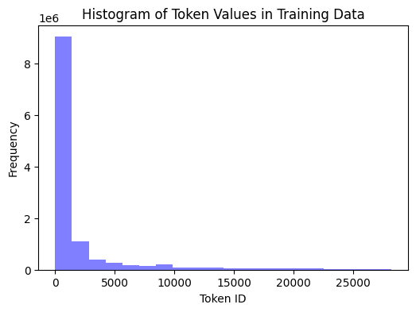

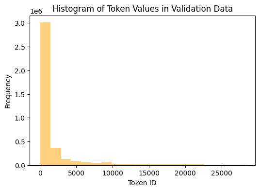

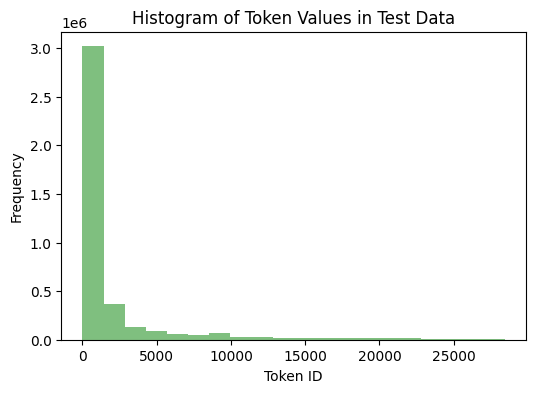

```python
# plotting histogram for token values in train data
plt.figure(figsize=(6, 4))
plt.hist(train_token_ids, bins=20, alpha=0.5, color='blue')
plt.title('Histogram of Token Values in Training Data')
plt.xlabel('Token ID')
plt.ylabel('Frequency')
plt.show()

plt.figure(figsize=(6, 4))
plt.hist(val_token_ids, bins=20, alpha=0.5, color='orange')
plt.title('Histogram of Token Values in Validation Data')
plt.xlabel('Token ID')
plt.ylabel('Frequency')
plt.show()

plt.figure(figsize=(6, 4))
plt.hist(test_token_ids, bins=20, alpha=0.5, color='green')
plt.title('Histogram of Token Values in Test Data')
plt.xlabel('Token ID')
plt.ylabel('Frequency')
plt.show()
```

```python
# top 5 most common tokens in the training dataset
top_5_train_tokens = Counter(train_token_ids).most_common(5)
top_5_decoded = [tokenizer.decode([token_id]) for token_id, _ in top_5_train_tokens]
df_top_tokens = pd.DataFrame({
    'Token ID': [token_id for token_id, _ in top_5_train_tokens],
    'Decoded': top_5_decoded,
    'Frequency': [freq for _, freq in top_5_train_tokens]
})

df_top_tokens
```

|  | Token ID | Decoded | Frequency |
| --- | --- | --- | --- |
| 0 | 0 | [PAD] | 4293191 |
| 1 | 119 | . | 317646 |
| 2 | 1103 | the | 275924 |
| 3 | 117 | , | 259234 |
| 4 | 170 | a | 153504 |

All three histograms display a similar pattern, with a high frequency of lower token IDs and a rapid decline as the token ID increases. This indicates a concentration of usage in a small subset of the tokenizer's vocabulary, which is common in natural language where certain words are used more frequently than others.

In the training dataset, the top five occurring tokens are:

- Token ID 0, represented as [PAD], occurs 4,293,191 times. This token is used for padding shorter sequences to the required input length for the BERT model.
- Token ID 119, represented as '.', occurs 317,646 times. It indicates that the period punctuation mark is a common sentence delimiter in the dataset.
- Token ID 1103, represented as 'the', occurs 275,924 times. This is the definite article in English and is typically one of the most common words in the language.
- Token ID 117, represented as ',', occurs 259,234 times. Commas are commonly used punctuation marks in English.
- Token ID 170, represented as 'a', occurs 153,504 times. It is the indefinite article in English, another commonly used word.

These tokens are predominantly structural elements of the English language, comprising padding, punctuation, and common articles, which explains their high frequency of occurrence. The predominance of these tokens is expected given their role in sentence structure and grammar in natural language text.

```python
# get one batch and one sample from data loader
for batch in train_data_loader:
    inputs = {
        'input_ids': batch['input_ids'][0].unsqueeze(0),
        'attention_mask': batch['attention_mask'][0].unsqueeze(0)
    }
    # feed the inputs to the BERT model.
    with torch.no_grad():
        outputs = bert_model(**inputs)
    # 'hidden_states' is the output of the final layer of BERT
    hidden_states = outputs.last_hidden_state
    # 'pooled_output' is a summary of the content
    pooled_output = outputs.pooler_output
    break

print(f"Input IDs dimension: {inputs['input_ids'].shape}")
print(f"Attention mask dimension: {inputs['attention_mask'].shape}")
print(f"Hidden state dimension: {hidden_states.shape}")
print(f"Pooled output dimension: {pooled_output.shape}")
```

```
Input IDs dimension: torch.Size([1, 400])
Attention mask dimension: torch.Size([1, 400])
Hidden state dimension: torch.Size([1, 400, 768])
Pooled output dimension: torch.Size([1, 768])
```

- Input IDs Dimension ([1, 400]): The first dimension size 1 indicates the batch size (one sample in this batch). The second dimension size 400 is the sequence length, representing the number of token IDs in the input sequence.
- Attention Mask Dimension ([1, 400]): Similar to the input IDs, this tensor has a shape corresponding to a single input sequence with a length of 400. The attention mask specifies which tokens in the sequence are actual words (1) versus padding (0), enabling the model to differentiate and focus only on meaningful input during processing.
- Hidden State Dimension ([1, 400, 768]): This tensor contains the output from the final layer of BERT for each token in the input sequence. The first dimension 1 is the batch size, the second dimension 400 is the sequence length (matching the input IDs and attention mask), and the third dimension 768 is the size of the hidden layers/features within the BERT model.
- Pooled Output Dimension ([1, 768]): This tensor is derived from the hidden state of the special [CLS] token (the first token of the sequence). The size 1 is the batch size, and 768 represents the hidden layer size. This pooled output is often used for classification tasks.

**The sizes of these dimensions are affected by:**

- The batch size (1 in this case), which is determined by how many samples are processing simultaneously.
- The sequence length (400 in this case), which is pre-defined and is to add padding to shorter sequences and truncating longer ones to a fixed size to feed to model.
- The hidden size (768 for BERT base), which is a fixed feature of the model architecture indicating the number of neurons in the hidden layers.

## 2. Model Architecture

```python
device = torch.device("cuda" if torch.cuda.is_available() else "cpu")

class SentimentClassifierPooled(nn.Module):

  def __init__(self, embedding_dim, n_classes, drop):
    super(SentimentClassifierPooled, self).__init__()
    self.drop = nn.Dropout(p=drop)
    self.fc1 = nn.Linear(embedding_dim, 512)
    self.fc2 = nn.Linear(512, 256)
    self.fc3 = nn.Linear(256, n_classes)
    # since Cross entropy loss already include softmax, i won't apply it here

  def forward(self, embeddings):
    x = self.drop(embeddings)
    x = F.relu(self.fc1(x))
    x = self.drop(x)
    x = F.relu(self.fc2(x))
    x = self.drop(x)
    x = self.fc3(x)

    return x
```

```python
class SentimentClassifierLast(nn.Module):

  def __init__(self, embedding_dim, n_classes, drop):
    super(SentimentClassifierLast, self).__init__()
    self.drop = nn.Dropout(p=drop)
    self.fc1 = nn.Linear(embedding_dim, 512)
    self.fc2 = nn.Linear(512, 128)
    self.fc3 = nn.Linear(128, n_classes)

  def forward(self, embeddings):
    x = self.drop(embeddings)
    x = F.relu(self.fc1(x))
    x = self.drop(x)
    x = F.relu(self.fc2(x))
    x = self.drop(x)
    x = self.fc3(x)
    return x
```

### Convert data to BERT embedding

```python
def save_labels_from_dataloader(data_loader, file_name):
    all_labels = []

    # Iterate through the DataLoader and accumulate labels
    for batch in data_loader:
        all_labels.append(batch['targets'])

    # Concatenate all labels into a single tensor
    all_labels_tensor = torch.cat(all_labels, dim=0)

    # Save the tensor to a file
    torch.save(all_labels_tensor, file_name)
```

```python
save_labels_from_dataloader(train_data_loader, 'train_labels.pt')
save_labels_from_dataloader(val_data_loader, 'val_labels.pt')
save_labels_from_dataloader(test_data_loader, 'test_labels.pt')
```

```python
import h5py
from tqdm import tqdm

tokenizer = BertTokenizer.from_pretrained('bert-base-cased')
model = BertModel.from_pretrained('bert-base-cased')
device = torch.device("cuda" if torch.cuda.is_available() else "cpu")
model.to(device)
model.eval()

def data_to_embedding_pooled(data_loader, file_name):
    embeddings = []
    with torch.no_grad():
        for batch in tqdm(data_loader, total=len(data_loader)):
            input_ids = batch['input_ids'].to(device)
            attention_mask = batch['attention_mask'].to(device)

            outputs = model(input_ids=input_ids, attention_mask=attention_mask)
            pooled_output = outputs[1]
            embeddings.append(pooled_output.cpu().numpy())  # Convert to CPU and then to numpy

    # Convert the list of arrays to a single numpy array
    embeddings = np.vstack(embeddings)

    # Save the numpy array to an HDF5 file
    with h5py.File(file_name, 'w') as f:
        f.create_dataset('embeddings', data=embeddings)

# saving embedding
data_to_embedding_pooled(train_data_loader, 'train_embedding_pooled.h5')
data_to_embedding_pooled(val_data_loader, 'val_embedding_pooled.h5')
data_to_embedding_pooled(test_data_loader, 'test_embedding_pooled.h5')
```

```python
tokenizer = BertTokenizer.from_pretrained('bert-base-cased')
model = BertModel.from_pretrained('bert-base-cased')
device = torch.device("cuda" if torch.cuda.is_available() else "cpu")
model.to(device)
model.eval()
def data_to_embedding_cls(data_loader, file_name):
    embeddings = []
    with torch.no_grad():
        for batch in tqdm(data_loader, total=len(data_loader)):
            input_ids = batch['input_ids'].to(device)
            attention_mask = batch['attention_mask'].to(device)

            outputs = model(input_ids=input_ids, attention_mask=attention_mask)
            cls_token_embedding = outputs.last_hidden_state[:, 0, :]  # Extract the [CLS] token's embeddings
            embeddings.append(cls_token_embedding.cpu().numpy())

    # Convert the list of arrays to a single numpy array
    embeddings = np.vstack(embeddings)

    # Save the numpy array to an HDF5 file
    with h5py.File(file_name, 'w') as f:
        f.create_dataset('embeddings', data=embeddings)

# saving embedding
data_to_embedding_cls(train_data_loader, 'train_embeddings_cls.h5')
data_to_embedding_cls(val_data_loader, 'val_embeddings_cls.h5')
data_to_embedding_cls(test_data_loader, 'test_embeddings_cls.h5')
```

```python
import h5py

class EmbeddingDataset(Dataset):
    def __init__(self, embedding_file, label_file):
        with h5py.File(embedding_file, 'r') as f:
            self.embeddings = f['embeddings'][:]

        self.labels = torch.load(label_file)

    def __len__(self):
        return len(self.labels)

    def __getitem__(self, idx):
        embedding = self.embeddings[idx]
        label = self.labels[idx]
        return {
            'embeddings': torch.tensor(embedding, dtype=torch.float),
            'targets': torch.tensor(label, dtype=torch.long)
        }
```

## 3. Training

```python
def get_accuracy(model, data):
    """ Compute the accuracy of the `model` across a dataset `data`

    Example usage:

    >>> model = MyRNN() # to be defined
    >>> get_accuracy(model, valid_loader) # the variable `valid_loader` is from above
    """

    model.eval()
    correct, total = 0, 0

    with torch.no_grad():
        for batch in data:
            embeddings = batch['embeddings'].to(device)
            labels = batch['targets'].to(device)

            outputs = model(embeddings)

            # Outputs are already probabilities, so we use argmax to get the predicted class
            _, predictions = torch.max(outputs, dim=1)

            # Update counts
            correct += (predictions == labels).sum().item()
            total += labels.size(0)

    accuracy = correct / total
    return accuracy
```

```python
# train_model function
from torch.optim import Adam
from torch.nn import CrossEntropyLoss

def train_model(model, train_loader, val_loader, epoch_num, lr, n_model):
    optimizer = Adam(model.parameters(), lr=lr)
    criterion = CrossEntropyLoss()
    device = torch.device("cuda" if torch.cuda.is_available() else "cpu")

    model.to(device)

    train_losses = []
    val_losses = []
    train_accuracies = []
    val_accuracies = []

    best_val_accuracy = 0

    print(f"Training with {epoch_num} epochs and learning rate {lr}")

    for epoch in range(epoch_num):
        model.train()
        train_loss = 0
        train_correct = 0
        train_total = 0

        for batch in train_loader:
            embeddings, labels = batch['embeddings'].to(device), batch['targets'].to(device)
            optimizer.zero_grad()

            outputs = model(embeddings)
            loss = criterion(outputs, labels)
            loss.backward()
            optimizer.step()

            train_loss += loss.item()

        train_accuracy = get_accuracy(model, train_loader)
        train_losses.append(train_loss / len(train_loader))
        train_accuracies.append(train_accuracy)

        model.eval()
        val_loss = 0
        val_correct = 0
        val_total = 0
        with torch.no_grad():
            for batch in val_loader:
                embeddings, labels = batch['embeddings'].to(device), batch['targets'].to(device)

                outputs = model(embeddings)
                loss = criterion(outputs, labels)

                val_loss += loss.item()

        val_accuracy = get_accuracy(model, val_loader)
        val_losses.append(val_loss / len(val_loader))
        val_accuracies.append(val_accuracy)

        print(f'Epoch [{epoch}/{epoch_num-1}]:\n Train Loss: {train_losses[-1]:.4f}, Train Acc: {train_accuracies[-1]:.4f}\n Val Loss: {val_losses[-1]:.4f}, Val Acc: {val_accuracies[-1]:.4f}')

        if val_accuracies[-1] > best_val_accuracy:
            best_val_accuracy = val_accuracies[-1]
            model_filename = f"{n_model}_model_lr{lr}_epoch{epoch}.pth"
            best_model_path = model_filename
    torch.save(model.state_dict(), best_model_path)
    print(f'Saved new best model to {best_model_path}, Best Val Accuracy {best_val_accuracy}')

    plt.figure(figsize=(10, 4))
    plt.subplot(1, 2, 1)
    plt.plot(train_losses, label='Train Loss')
    plt.plot(val_losses, label='Validation Loss')
    plt.title('Loss over epochs')
    plt.legend()

    plt.subplot(1, 2, 2)
    plt.plot(train_accuracies, label='Train Accuracy')
    plt.plot(val_accuracies, label='Validation Accuracy')
    plt.title('Accuracy over epochs')
    plt.legend()

    plt.show()
```

#### Model 1

Fixed hyperparameters:

- embedding_dim = 768
- n_classes = 2

Tuned hyperparameters:

- drop = 0.4
- lr = 0.00005
- epoch_num = 25
- bs = 8

```
Training with 25 epochs and learning rate 5e-05
```

```
Epoch [0/24]:
 Train Loss: 0.6560, Train Acc: 0.6890
 Val Loss: 0.5905, Val Acc: 0.6977
Epoch [1/24]:
 Train Loss: 0.6185, Train Acc: 0.6794
 Val Loss: 0.5789, Val Acc: 0.6932
Epoch [2/24]:
 Train Loss: 0.6068, Train Acc: 0.6942
 Val Loss: 0.5650, Val Acc: 0.7048
Epoch [3/24]:
 Train Loss: 0.5998, Train Acc: 0.7182
 Val Loss: 0.5494, Val Acc: 0.7325
Epoch [4/24]:
 Train Loss: 0.5961, Train Acc: 0.7256
 Val Loss: 0.5452, Val Acc: 0.7379
Epoch [5/24]:
 Train Loss: 0.5939, Train Acc: 0.7263
 Val Loss: 0.5382, Val Acc: 0.7399
Epoch [6/24]:
 Train Loss: 0.5898, Train Acc: 0.7245
 Val Loss: 0.5365, Val Acc: 0.7391
Epoch [7/24]:
 Train Loss: 0.5890, Train Acc: 0.7298
 Val Loss: 0.5391, Val Acc: 0.7436
Epoch [8/24]:
 Train Loss: 0.5867, Train Acc: 0.7307
 Val Loss: 0.5350, Val Acc: 0.7457
Epoch [9/24]:
 Train Loss: 0.5842, Train Acc: 0.7367
 Val Loss: 0.5504, Val Acc: 0.7425
Epoch [10/24]:
 Train Loss: 0.5850, Train Acc: 0.7391
 Val Loss: 0.5332, Val Acc: 0.7480
Epoch [11/24]:
 Train Loss: 0.5822, Train Acc: 0.7191
 Val Loss: 0.5380, Val Acc: 0.7331
Epoch [12/24]:
 Train Loss: 0.5812, Train Acc: 0.7303
 Val Loss: 0.5232, Val Acc: 0.7456
Epoch [13/24]:
```

[output cut: 21 more lines]

```
 Train Loss: 0.5748, Train Acc: 0.7461
 Val Loss: 0.5148, Val Acc: 0.7597
Epoch [21/24]:
 Train Loss: 0.5778, Train Acc: 0.7338
 Val Loss: 0.5340, Val Acc: 0.7464
Epoch [22/24]:
 Train Loss: 0.5743, Train Acc: 0.7438
 Val Loss: 0.5256, Val Acc: 0.7579
Epoch [23/24]:
 Train Loss: 0.5738, Train Acc: 0.7457
 Val Loss: 0.5263, Val Acc: 0.7593
Epoch [24/24]:
 Train Loss: 0.5734, Train Acc: 0.7499
 Val Loss: 0.5233, Val Acc: 0.7637
Saved new best model to 1_model_lr5e-05_epoch24.pth, Best Val Accuracy 0.7637333333333334
```

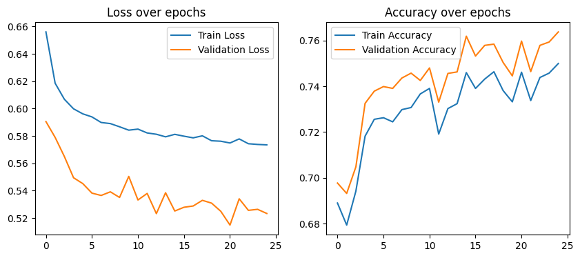

```python
# Model 1
n_model = 1 #SentimentClassifierPooled
embedding_dim = 768
n_classes = 2

drop = 0.4
lr = 0.00005
epoch_num = 25
bs = 8

train_dataset = EmbeddingDataset('train_embedding_pooled.h5', 'train_labels.pt')
train_loader = DataLoader(train_dataset, batch_size=bs, shuffle=True)
val_dataset = EmbeddingDataset('val_embedding_pooled.h5', 'val_labels.pt')
val_loader = DataLoader(val_dataset, batch_size=bs)
model = SentimentClassifierPooled(embedding_dim, n_classes, drop)
train_model(model, train_loader, val_loader, epoch_num, lr, n_model)
```

**Explanation**

For first fine-tuning model, I selected SentimentClassifierPooled model. The hyperparameters I adjusted include the learning rate, batch size, dropout rate, and the number of epochs during training.

- Learning Rate (lr): I chose a learning rate of 0.00005. This relatively small learning rate was selected to allow the model to gradually converge to a local minimum and avoid overshooting. A lower learning rate can sometimes lead to better generalization but at the cost of longer training times.
- Batch Size (bs): I set the batch size to 8. This is a compromise between the computational efficiency of larger batches and the stochastic nature of smaller batches that can help escape local minima.
- Dropout Rate (drop): A dropout rate of 0.4 was used to prevent overfitting. Dropout is a regularization technique where randomly selected neurons are ignored during training, which helps the model to learn more robust features that are not reliant on any small set of neurons.
- Epochs (epoch_num): I trained the model for 25 epochs. This was chosen to allow sufficient training time for patterns to be learned, but not too many as to cause overfitting, as indicated by the validation loss starting to increase or validation accuracy to plateau.

The model's learning trajectory is underscored by a declining trend in both training and validation losses. The validation accuracy exhibits an overall improvement, peaking at about 76.37% at the 24th epoch, demonstrating effective learning and the positive influence of the hyperparameter choices over time. The lower validation loss compared to the training loss can be explained by the model's use of dropout during training, which is disabled during evaluation, resulting in better performance on the validation set.

However, the lack of smoothness in the training and validation curves indicates instability in the learning process, which is suboptimal as it can lead to less predictable model performance; therefore, refining hyperparameters may result in smoother curves and improved training stability.

#### Model 2

Fixed hyperparameters:

- embedding_dim = 768
- n_classes = 2

Tuned hyperparameters:

- drop = 0.3
- lr = 0.00002
- epoch_num = 25
- bs = 14

```
Training with 25 epochs and learning rate 2e-05
```

```
Epoch [0/24]:
 Train Loss: 0.6638, Train Acc: 0.6506
 Val Loss: 0.6180, Val Acc: 0.6619
Epoch [1/24]:
 Train Loss: 0.6219, Train Acc: 0.7031
 Val Loss: 0.5707, Val Acc: 0.7105
Epoch [2/24]:
 Train Loss: 0.6020, Train Acc: 0.7148
 Val Loss: 0.5501, Val Acc: 0.7253
Epoch [3/24]:
 Train Loss: 0.5937, Train Acc: 0.7088
 Val Loss: 0.5485, Val Acc: 0.7205
Epoch [4/24]:
 Train Loss: 0.5852, Train Acc: 0.7180
 Val Loss: 0.5360, Val Acc: 0.7319
Epoch [5/24]:
 Train Loss: 0.5826, Train Acc: 0.7373
 Val Loss: 0.5235, Val Acc: 0.7472
Epoch [6/24]:
 Train Loss: 0.5794, Train Acc: 0.7357
 Val Loss: 0.5201, Val Acc: 0.7484
Epoch [7/24]:
 Train Loss: 0.5790, Train Acc: 0.7268
 Val Loss: 0.5261, Val Acc: 0.7413
Epoch [8/24]:
 Train Loss: 0.5726, Train Acc: 0.7431
 Val Loss: 0.5135, Val Acc: 0.7563
Epoch [9/24]:
 Train Loss: 0.5712, Train Acc: 0.7313
 Val Loss: 0.5190, Val Acc: 0.7464
Epoch [10/24]:
 Train Loss: 0.5708, Train Acc: 0.7410
 Val Loss: 0.5123, Val Acc: 0.7559
Epoch [11/24]:
 Train Loss: 0.5702, Train Acc: 0.7351
 Val Loss: 0.5165, Val Acc: 0.7507
Epoch [12/24]:
 Train Loss: 0.5674, Train Acc: 0.7434
 Val Loss: 0.5117, Val Acc: 0.7579
Epoch [13/24]:
```

[output cut: 21 more lines]

```
 Train Loss: 0.5614, Train Acc: 0.7509
 Val Loss: 0.5051, Val Acc: 0.7648
Epoch [21/24]:
 Train Loss: 0.5619, Train Acc: 0.7557
 Val Loss: 0.5115, Val Acc: 0.7692
Epoch [22/24]:
 Train Loss: 0.5623, Train Acc: 0.7554
 Val Loss: 0.5081, Val Acc: 0.7681
Epoch [23/24]:
 Train Loss: 0.5589, Train Acc: 0.7483
 Val Loss: 0.5014, Val Acc: 0.7629
Epoch [24/24]:
 Train Loss: 0.5577, Train Acc: 0.7429
 Val Loss: 0.5086, Val Acc: 0.7544
Saved new best model to 2_model_lr2e-05_epoch21.pth, Best Val Accuracy 0.7692
```

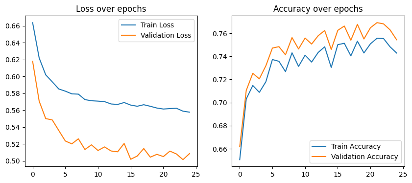

```python
# Model 2
n_model = 2 #SentimentClassifierPooled
embedding_dim = 768
n_classes = 2

drop = 0.3
lr = 0.00002
epoch_num = 25
bs = 14

train_dataset = EmbeddingDataset('train_embedding_pooled.h5', 'train_labels.pt')
train_loader = DataLoader(train_dataset, batch_size=bs, shuffle=True)
val_dataset = EmbeddingDataset('val_embedding_pooled.h5', 'val_labels.pt')
val_loader = DataLoader(val_dataset, batch_size=bs)
model = SentimentClassifierPooled(embedding_dim, n_classes, drop)
train_model(model, train_loader, val_loader, epoch_num, lr, n_model)
```

**Explanation**

For the second iteration of fine-tuning, Model 2, the SentimentClassifierPooled model was again utilized. The hyperparameter adjustments made were designed to refine the model's performance further based on the insights gained from the previous iteration.

- Learning Rate (lr): The learning rate was reduced to 0.00002, further slowing the training process in hopes of achieving a smoother convergence and possibly better generalization, as indicated by the non-smooth trends observed previously.
- Batch Size (bs): The batch size was increased to 14, which may provide a better balance between the efficiency of computation and the benefits of stochastic gradient descent, aiding in a more stable and consistent convergence pattern.
- Dropout Rate (drop): The dropout rate was slightly decreased to 0.3, aiming to find a better trade-off between regularization and the ability to learn complex patterns, which might contribute to a steadier decrease in validation loss.
- Epochs (epoch_num): The model continued to be trained for 25 epochs, maintaining a consistent duration for learning while monitoring for signs of overfitting or underfitting.

In Model 2, the best validation accuracy achieved was approximately 76.92% at epoch 21, reflecting a slight improvement from Model 1. The training and validation curves for Model 2 suggest a more stable learning process with less volatility, yet there remains room for achieving smoother convergence. These observations indicate that the adjustments to the learning rate, batch size, and dropout rate have positively impacted the model's ability to generalize and learn from the data.

#### Model 3

Fixed hyperparameters:

- embedding_dim = 768
- n_classes = 2

Tuned hyperparameters:

- drop = 0.2
- lr = 0.00001
- epoch_num = 25
- bs = 12

```
Training with 25 epochs and learning rate 1e-05
```

```
Epoch [0/24]:
 Train Loss: 0.6177, Train Acc: 0.7482
 Val Loss: 0.5162, Val Acc: 0.7633
Epoch [1/24]:
 Train Loss: 0.5054, Train Acc: 0.7858
 Val Loss: 0.4549, Val Acc: 0.7916
Epoch [2/24]:
 Train Loss: 0.4747, Train Acc: 0.7912
 Val Loss: 0.4403, Val Acc: 0.8036
Epoch [3/24]:
 Train Loss: 0.4624, Train Acc: 0.8013
 Val Loss: 0.4253, Val Acc: 0.8104
Epoch [4/24]:
 Train Loss: 0.4552, Train Acc: 0.8039
 Val Loss: 0.4197, Val Acc: 0.8132
Epoch [5/24]:
 Train Loss: 0.4501, Train Acc: 0.8050
 Val Loss: 0.4166, Val Acc: 0.8139
Epoch [6/24]:
 Train Loss: 0.4461, Train Acc: 0.8099
 Val Loss: 0.4099, Val Acc: 0.8189
Epoch [7/24]:
 Train Loss: 0.4435, Train Acc: 0.8113
 Val Loss: 0.4068, Val Acc: 0.8187
Epoch [8/24]:
 Train Loss: 0.4405, Train Acc: 0.8127
 Val Loss: 0.4044, Val Acc: 0.8205
Epoch [9/24]:
 Train Loss: 0.4410, Train Acc: 0.8149
 Val Loss: 0.4014, Val Acc: 0.8235
Epoch [10/24]:
 Train Loss: 0.4365, Train Acc: 0.8144
 Val Loss: 0.4011, Val Acc: 0.8224
Epoch [11/24]:
 Train Loss: 0.4345, Train Acc: 0.8159
 Val Loss: 0.3991, Val Acc: 0.8232
Epoch [12/24]:
 Train Loss: 0.4356, Train Acc: 0.8183
 Val Loss: 0.3966, Val Acc: 0.8243
Epoch [13/24]:
```

[output cut: 21 more lines]

```
 Train Loss: 0.4253, Train Acc: 0.8233
 Val Loss: 0.3879, Val Acc: 0.8279
Epoch [21/24]:
 Train Loss: 0.4260, Train Acc: 0.8213
 Val Loss: 0.3897, Val Acc: 0.8263
Epoch [22/24]:
 Train Loss: 0.4237, Train Acc: 0.8236
 Val Loss: 0.3872, Val Acc: 0.8289
Epoch [23/24]:
 Train Loss: 0.4251, Train Acc: 0.8239
 Val Loss: 0.3878, Val Acc: 0.8287
Epoch [24/24]:
 Train Loss: 0.4249, Train Acc: 0.8224
 Val Loss: 0.3894, Val Acc: 0.8265
Saved new best model to 3_model_lr1e-05_epoch22.pth, Best Val Accuracy 0.8289333333333333
```

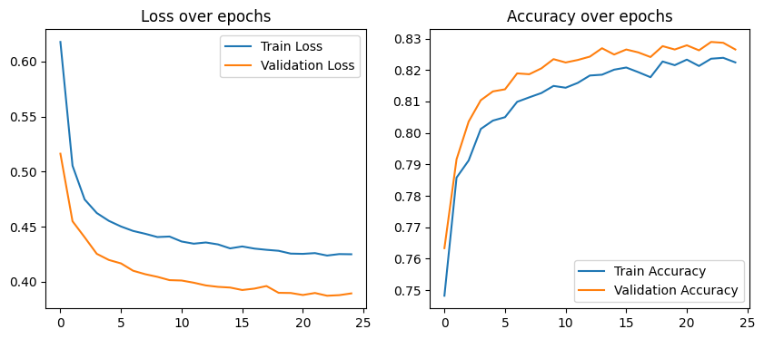

```python
# Model 3
n_model = 3 #SentimentClassifierLast
embedding_dim = 768
n_classes = 2

drop = 0.2
lr = 0.00001
epoch_num = 25
bs = 12

train_dataset = EmbeddingDataset('train_embeddings_cls.h5', 'train_labels.pt')
train_loader = DataLoader(train_dataset, batch_size=bs, shuffle=True)
val_dataset = EmbeddingDataset('val_embeddings_cls.h5', 'val_labels.pt')
val_loader = DataLoader(val_dataset, batch_size=bs)
model = SentimentClassifierLast(embedding_dim, n_classes, drop)
train_model(model, train_loader, val_loader, epoch_num, lr, n_model)
```

**Explanation**

For Model 3's fine-tuning, the SentimentClassifierLast was deployed with a focus on further refining the model's predictive capabilities. Hyperparameter optimization was once again the strategy for improving the model's performance.

- Learning Rate (lr): The learning rate was set to an even lower figure of 0.00001, intending to ensure meticulous weight adjustments and to facilitate more nuanced model training.
- Batch Size (bs): A batch size of 12 was chosen, aiming to strike a delicate balance between training stability and learning granularity, which is especially crucial in stochastic training environments.
- Dropout Rate (drop): The dropout was adjusted to 0.2, aiming to reduce regularization slightly, based on the hypothesis that a lower dropout could allow the network to retain more information between epochs.
- Epochs (epoch_num): As with the previous models, Model 3 was trained over 25 epochs to maintain consistency in the evaluation of hyperparameter impacts.

The best validation accuracy observed was about 82.89% at epoch 22, suggesting that the lower learning rate and adjusted dropout contributed positively to model accuracy. The training and validation loss curves in Model 3 exhibited a steady and more synchronized descent, indicating improved model stability. These modifications in the learning rate, batch size, and dropout rate seem to have effectively addressed previous models' learning instabilities and contributed to the overall betterment of model performance.

#### Model 4

Fixed hyperparameters:

- embedding_dim = 768
- n_classes = 2

Tuned hyperparameters:

- drop = 0.3
- lr = 0.00003
- epoch_num = 25
- bs = 9

```
Training with 25 epochs and learning rate 3e-05
```

```
Epoch [0/24]:
 Train Loss: 0.5458, Train Acc: 0.7910
 Val Loss: 0.4396, Val Acc: 0.7996
Epoch [1/24]:
 Train Loss: 0.4731, Train Acc: 0.7970
 Val Loss: 0.4267, Val Acc: 0.8091
Epoch [2/24]:
 Train Loss: 0.4630, Train Acc: 0.8070
 Val Loss: 0.4127, Val Acc: 0.8188
Epoch [3/24]:
 Train Loss: 0.4583, Train Acc: 0.8079
 Val Loss: 0.4097, Val Acc: 0.8163
Epoch [4/24]:
 Train Loss: 0.4540, Train Acc: 0.8120
 Val Loss: 0.4050, Val Acc: 0.8216
Epoch [5/24]:
 Train Loss: 0.4497, Train Acc: 0.8106
 Val Loss: 0.4078, Val Acc: 0.8179
Epoch [6/24]:
 Train Loss: 0.4491, Train Acc: 0.8155
 Val Loss: 0.4026, Val Acc: 0.8243
Epoch [7/24]:
 Train Loss: 0.4469, Train Acc: 0.8153
 Val Loss: 0.4017, Val Acc: 0.8243
Epoch [8/24]:
 Train Loss: 0.4449, Train Acc: 0.8149
 Val Loss: 0.4030, Val Acc: 0.8220
Epoch [9/24]:
 Train Loss: 0.4461, Train Acc: 0.8184
 Val Loss: 0.3951, Val Acc: 0.8253
Epoch [10/24]:
 Train Loss: 0.4403, Train Acc: 0.8195
 Val Loss: 0.3968, Val Acc: 0.8249
Epoch [11/24]:
 Train Loss: 0.4397, Train Acc: 0.8216
 Val Loss: 0.3977, Val Acc: 0.8259
Epoch [12/24]:
 Train Loss: 0.4367, Train Acc: 0.8178
 Val Loss: 0.3976, Val Acc: 0.8257
Epoch [13/24]:
```

[output cut: 21 more lines]

```
 Train Loss: 0.4264, Train Acc: 0.8293
 Val Loss: 0.3888, Val Acc: 0.8297
Epoch [21/24]:
 Train Loss: 0.4261, Train Acc: 0.8257
 Val Loss: 0.3974, Val Acc: 0.8297
Epoch [22/24]:
 Train Loss: 0.4258, Train Acc: 0.8313
 Val Loss: 0.3901, Val Acc: 0.8335
Epoch [23/24]:
 Train Loss: 0.4257, Train Acc: 0.8312
 Val Loss: 0.3852, Val Acc: 0.8296
Epoch [24/24]:
 Train Loss: 0.4231, Train Acc: 0.8287
 Val Loss: 0.3957, Val Acc: 0.8328
Saved new best model to 4_model_lr3e-05_epoch22.pth, Best Val Accuracy 0.8334666666666667
```

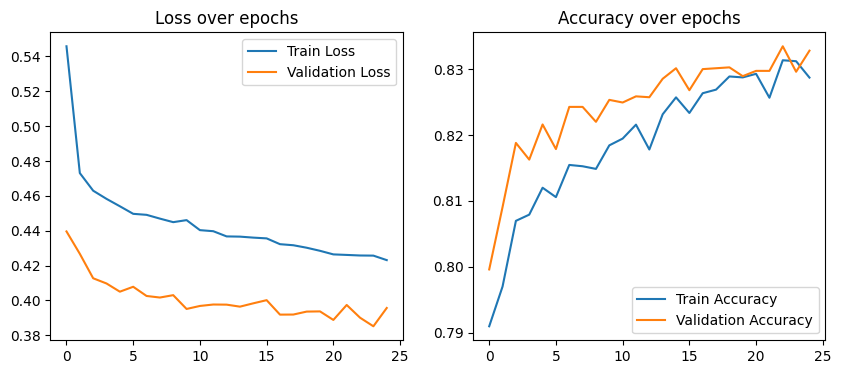

```python
# Model 4
n_model = 4 #SentimentClassifierLast
embedding_dim = 768
n_classes = 2

drop = 0.3
lr = 0.00003
epoch_num = 25
bs = 9


train_dataset = EmbeddingDataset('train_embeddings_cls.h5', 'train_labels.pt')
train_loader = DataLoader(train_dataset, batch_size=bs, shuffle=True)
val_dataset = EmbeddingDataset('val_embeddings_cls.h5', 'val_labels.pt')
val_loader = DataLoader(val_dataset, batch_size=bs)
model = SentimentClassifierLast(embedding_dim, n_classes, drop)
train_model(model, train_loader, val_loader, epoch_num, lr, n_model)
```

**Explanation**

The fourth fine tuning, leveraging the SentimentClassifierLast, involved strategic hyperparameter tuning aimed at refining the training process and enhancing model accuracy.

- Learning Rate (lr): The learning rate was slightly increased to 0.00003, with the intention to test whether a slightly faster learning pace could maintain or improve the balance between convergence speed and stability observed in the previous model.
- Batch Size (bs): The batch size was decreased to 9 to explore the effects of a smaller batch on the gradient updates and overall model performance.
- Dropout Rate (drop): Maintaining a dropout rate of 0.3, the model aimed to balance the benefit of regularization while still allowing for sufficient feature learning during training.
- Epochs (epoch_num): Consistent with prior models, the training proceeded for 25 epochs, offering a uniform timeframe to assess the effects of the newly adjusted hyperparameters.

Model 4 achieved a validation accuracy of approximately 83.34% at epoch 22, indicating a marginal improvement over Model 3. The training and validation loss curves showed a consistent reduction in loss, while the accuracy graph displayed an ascending trend, albeit with some fluctuations that suggest further potential for smoothing through hyperparameter refinement. This indicates that while the adjusted learning rate and batch size have had a positive impact, there may still be opportunities to optimize these parameters for even better model performance.

## Part 4. Evaluation [10 pt]

### Part (i) [3pt RESULT]

Report the final test accuracy of your best BERT-based model. Then summarize in a pandas dataframe the accuracy obtained on the training, validation, and test data of your best models from Part A and B.

How does the BERT model compare to the approach in part A using only LSTM? Are the results what you expected? Explain.

```python
# evaluate model on test
embedding_dim = 768
n_classes = 2
drop = 0.2
bs = 12
model = SentimentClassifierLast(embedding_dim, n_classes, drop)
model = model.to(device)
best_model_path = '3_model_lr1e-05_epoch22.pth'
model.load_state_dict(torch.load(best_model_path))
test_dataset = EmbeddingDataset('test_embeddings_cls.h5', 'test_labels.pt')
test_loader = DataLoader(test_dataset, batch_size=bs)
test_accuracy = get_accuracy(model, test_loader)
print(f"Final Test Accuracy: {test_accuracy:.4f}")
```

```
Final Test Accuracy: 0.8129
```

```python
# comparison
data = {
    'Test Accuracy': [0.8129, 0.84710],
    'Dropout Rate': [0.2, 0.4],
    'Learning Rate': [0.00001, 0.0003],
    'Number of Epochs': [25, 8],
    'Batch Size': [12, 32],
    'Best Model Path': ['3_model_lr1e-05_epoch22.pth', 'model_SentimentRNN_bs32_lr0.0003_epoch6.pth']
}
model_comparison_df = pd.DataFrame(data)
model_comparison_df = model_comparison_df.T
model_comparison_df.columns = ['BERT', 'LSTM']
model_comparison_df
```

|  | BERT | LSTM |
| --- | --- | --- |
| Test Accuracy | 0.8129 | 0.8471 |
| Dropout Rate | 0.2 | 0.4 |
| Learning Rate | 0.00001 | 0.0003 |
| Number of Epochs | 25 | 8 |
| Batch Size | 12 | 32 |
| Best Model Path | 3_model_lr1e-05_epoch22.pth | model_SentimentRNN_bs32_lr0.0003_epoch6.pth |

**Analysis and Explanation**

The best model from the iterations is Model 3, which was selected based on its stable learning trajectory, consistent loss decrease over the epochs and relative high accuracy achievement. Although Model 4 achieved a slightly higher validation accuracy, the decision to choose Model 3 was informed by the smoother curves and the model's reliability, which often translates to better generalization on unseen data. A stable learning curve can be indicative of a model learning meaningful patterns rather than memorizing the training data, which is crucial for performance on real-world data.

```python
# FPR FNR for BERT Part-B
def get_rates(model, data_loader):
    device = torch.device('cuda' if torch.cuda.is_available() else 'cpu')
    model.eval()
    correct, total = 0, 0
    false_positive_count, false_negative_count = 0, 0
    true_positive_count, true_negative_count = 0, 0

    with torch.no_grad():
        for batch in data_loader:
            embeddings = batch['embeddings'].to(device)
            labels = batch['targets'].to(device)

            outputs = model(embeddings)
            _, predictions = torch.max(outputs, dim=1)

            # Update counts
            correct += (predictions == labels).sum().item()
            total += labels.size(0)

            # Calculate false positives, false negatives, true positives, and true negatives
            false_positive_count += ((predictions == 1) & (labels == 0)).sum().item()
            false_negative_count += ((predictions == 0) & (labels == 1)).sum().item()
            true_positive_count += ((predictions == 1) & (labels == 1)).sum().item()
            true_negative_count += ((predictions == 0) & (labels == 0)).sum().item()

    # Calculate rates
    false_positive_rate = false_positive_count / (false_positive_count + true_negative_count) if (false_positive_count + true_negative_count) > 0 else 0
    false_negative_rate = false_negative_count / (false_negative_count + true_positive_count) if (false_negative_count + true_positive_count) > 0 else 0

    return false_positive_rate, false_negative_rate
```

```python
embedding_dim = 768
n_classes = 2
drop = 0.2
bs = 12
train_dataset = EmbeddingDataset('train_embeddings_cls.h5', 'train_labels.pt')
train_loader = DataLoader(train_dataset, batch_size=bs)
val_dataset = EmbeddingDataset('val_embeddings_cls.h5', 'val_labels.pt')
val_loader = DataLoader(val_dataset, batch_size=bs)
test_dataset = EmbeddingDataset('test_embeddings_cls.h5', 'test_labels.pt')
test_loader = DataLoader(test_dataset, batch_size=bs)

model = SentimentClassifierLast(embedding_dim, n_classes, drop)
model = model.to(device)
best_model_path = '3_model_lr1e-05_epoch22.pth'
model.load_state_dict(torch.load(best_model_path))

train_fpr, train_fnr = get_rates(model, train_loader)
val_fpr, val_fnr = get_rates(model, val_loader)
test_fpr, test_fnr = get_rates(model, test_loader)

print(f"BERT: False Positive Rate: {test_fpr:.5f}, False Negative Rate: {test_fnr:.5f}")
```

```
BERT: False Positive Rate: 0.13077, False Negative Rate: 0.24327
```

```python
# calculate FPR FNR for LSTM part-A
def get_fpr_fnr(model, data_loader):
    device = torch.device('cuda' if torch.cuda.is_available() else 'cpu')
    model.eval()
    correct, total = 0, 0
    false_positive_count, false_negative_count = 0, 0
    true_positive_count, true_negative_count = 0, 0

    with torch.no_grad():
        for batch in data_loader:
            inputs, labels = batch['review'].to(device), batch['label'].to(device)

            # Assuming your model's forward method returns the output directly
            # and you are using a Sigmoid layer as the final layer
            outputs, _ = model(inputs, model.init_hidden(inputs.size(0)))
            predictions = outputs.round().squeeze()  # Convert probabilities to predictions

            # Update counts
            total += labels.size(0)
            correct += (predictions == labels).sum().item()

            # Calculate false positives, false negatives, true positives, and true negatives
            false_positive_count += ((predictions == 1) & (labels == 0)).sum().item()
            false_negative_count += ((predictions == 0) & (labels == 1)).sum().item()
            true_positive_count += ((predictions == 1) & (labels == 1)).sum().item()
            true_negative_count += ((predictions == 0) & (labels == 0)).sum().item()

    # Calculate rates
    false_positive_rate = false_positive_count / (false_positive_count + true_negative_count) if (false_positive_count + true_negative_count) > 0 else 0
    false_negative_rate = false_negative_count / (false_negative_count + true_positive_count) if (false_negative_count + true_positive_count) > 0 else 0

    model.train()  # Set the model back to training mode
    return false_positive_rate, false_negative_rate
```

```python
output_size = 1
vocab_size = len(stoi) + 1

embedding_dim = 64
hidden_dim = 256
n_layers = 2
drop = 0.4
batch_size = 32

train_dataset = ReviewDataset(X_train_padded, y_train_encoded)
val_dataset = ReviewDataset(X_val_padded, y_val_encoded)
test_dataset = ReviewDataset(X_test_padded, y_test_encoded)

train_loaderA = DataLoader(train_dataset, batch_size, shuffle=True)
val_loaderA = DataLoader(val_dataset, batch_size, shuffle=False)
test_loaderA = DataLoader(test_dataset, batch_size, shuffle=False)
modelA = SentimentRNN(vocab_size, output_size, embedding_dim, hidden_dim, n_layers, drop)
modelA = modelA.to(device)

best_modelA = 'model_SentimentRNN_bs32_lr0.0003_epoch6.pth'
modelA.load_state_dict(torch.load(best_modelA))

train_FPR, train_FNR = get_fpr_fnr(modelA, train_loaderA)
val_FPR, val_FNR = get_fpr_fnr(modelA, val_loaderA)
test_FPR, test_FNR = get_fpr_fnr(modelA, test_loaderA)
print(f"LSTM: False Positive Rate: {test_FPR:.5f}, False Negative Rate: {test_FNR:.5f}")
```

```
LSTM: False Positive Rate: 0.15250, False Negative Rate: 0.15071
```

```python
# comparison df

data = {
    'Training FPR': [train_FPR, train_fpr],
    'Training FNR': [train_FNR, train_fnr],
    'Validation FPR': [val_FPR, val_fpr],
    'Validation FNR': [val_FNR, val_fnr],
    'Test FPR': [test_FPR, test_fpr],
    'Test FNR': [test_FNR, test_fnr]
}


comparison_df = pd.DataFrame(data)
comparison_df = comparison_df.T
comparison_df.columns = ['LSTM (Part A)', 'BERT (Part B)']
comparison_df
```

|  | LSTM (Part A) | BERT (Part B) |
| --- | --- | --- |
| Training FPR | 0.080533 | 0.125895 |
| Training FNR | 0.084800 | 0.229006 |
| Validation FPR | 0.145132 | 0.116763 |
| Validation FNR | 0.161342 | 0.231516 |
| Test FPR | 0.152502 | 0.130771 |
| Test FNR | 0.150707 | 0.243272 |

**Analysis and explanation**

The higher FNR in BERT suggests it is more conservative in predicting the positive class, possibly missing out on true positive predictions. This could be due to BERT requiring more complex decision boundaries that the current model architecture isn't capturing, or it could indicate that the BERT model might need further tuning, more data, or a better-suited training regime to optimize its performance.

On the other hand, the lower FPR for BERT on validation and test sets compared to LSTM indicates that when BERT predicts an instance as positive, it is more likely to be correct than the LSTM model. This could be reflective of BERT's more nuanced understanding of language, even though it is not as confidently capturing all positive cases (as shown by the higher FNR).

Overall, while the BERT model's predictive performance isn't as strong as expected, the results provide valuable direction for further model improvements, such as architectural adjustments or more targeted training.

```python
with h5py.File('test_embeddings_cls.h5', 'r') as f:
    test_embeddings = f['embeddings'][:]

# Ensure alignment between the embeddings and the original data
assert len(df_test) == len(test_embeddings), "The embeddings and the original data must be aligned."

# Append embeddings to the original test dataset
df_test['embeddings'] = list(test_embeddings)

# Convert the modified DataFrame to a dataset
class TestDataset(Dataset):
    def __init__(self, dataframe, tokenizer, label_to_index):
        self.dataframe = dataframe
        self.tokenizer = tokenizer
        self.label_to_index = label_to_index

    def __len__(self):
        return len(self.dataframe)

    def __getitem__(self, idx):
        row = self.dataframe.iloc[idx]
        text = row['review']
        embeddings = row['embeddings']
        label = self.label_to_index[row['sentiment']]  # Convert string label to integer
        input_ids = self.tokenizer.encode(text, add_special_tokens=True)
        return {'embeddings': embeddings, 'targets': label, 'input_ids': input_ids, 'text': text}


label_to_index = {'positive': 1, 'negative': 0}
test_dataset = TestDataset(df_test, tokenizer, label_to_index)
test_data_loader = DataLoader(test_dataset)
```

```python
# misclassified cases (BERT)
from tqdm import tqdm

def bert_misclassified_cases(model, data_loader, num_cases=5):
    device = torch.device('cuda' if torch.cuda.is_available() else 'cpu')
    model.eval()
    misclassified_cases = []

    with torch.no_grad():
        for batch in tqdm(data_loader, total=len(data_loader)):
            embeddings = torch.tensor(batch['embeddings'], dtype=torch.float).to(device)
            targets = torch.tensor(batch['targets'], dtype=torch.long).to(device)

            outputs = model(embeddings)
            predictions = torch.argmax(outputs, dim=1)

            mismatches = (predictions != targets).nonzero(as_tuple=True)[0]

            for idx in mismatches:
                if len(misclassified_cases) >= num_cases:
                    break

                # Convert numerical labels to string labels
                predicted_label_str = "Positive" if predictions[idx].item() == 1 else "Negative"
                true_label_str = "Positive" if targets[idx].item() == 1 else "Negative"

                misclassified_cases.append({
                    'text': batch['text'][idx],  # Directly use the text from the batch
                    'predicted_label': predicted_label_str,
                    'true_label': true_label_str,
                })

    # Print out the review texts for misclassified cases
    for i, case in enumerate(misclassified_cases):
        print(f"Misclassified Sample {i+1}:")
        print(f"Review: {case['text']}")
        print(f"True Label: {case['true_label']}")
        print(f"Predicted Label: {case['predicted_label']}")
        print("-" * 50)

    return misclassified_cases

misclassified_samples = bert_misclassified_cases(model, test_data_loader, 10)
```

[output not shown]

```python
# missclassified cases (BERT)
misclassified_samples = misclassified_samples[4:9]
for i, sample in enumerate(misclassified_samples):
    print(f"\nMisclassified Sample {i+1}:")
    print(f"Review: {sample['text']}")
    print(f"True Label: {sample['true_label']}")
    print(f"Predicted Label: {sample['predicted_label']}")
    print("-" * 50)
```

```
Misclassified Sample 1:
Review: There are two things that I like about Elvira, and they're both bigger than she is and she keeps them covered up: her wit and her talent. A movie is the best thing to show off how funny she can be or how she commands attention. Looking like a combined clone of Morticia Adams and Anna Nicole …
True Label: Positive
Predicted Label: Negative
--------------------------------------------------

Misclassified Sample 2:
Review: I've read many unflattering comments regarding this film, and the only things I have seen that they all have in common are: "boring" and "unrealistic".<br /><br />First of all, they used real frickin' crocs! How much more realistic can you get? No CGI, no animatronics, no miniatures. Just a …
True Label: Positive
Predicted Label: Negative
--------------------------------------------------

Misclassified Sample 3:
Review: This movie looked like the out-takes of the deleted scenes from a high school film class experiment. It made no sense! It was well acted, but I only felt sorry for the characters because they had to appear in this slop. The alien machines were created with Pentium I technology and no creativ…
True Label: Negative
Predicted Label: Positive
--------------------------------------------------

Misclassified Sample 4:
Review: This Western was set in 1861 and had to do with the creation of the first transcontinental wireless lines that were laid by Western Union. While nice guy Dean Jagger (sporting lots of hair) did his best to get this done, there was a bad guy just waiting to undo this for his own selfish reaso…
True Label: Positive
Predicted Label: Negative
--------------------------------------------------

Misclassified Sample 5:
Review: Who doesn't know Largo Winch in the France-Belgium-Luxemburg trio (the three countries where the French "BD" or "Bandes Dessinées" are massively published) ? 18 years after the publication of the first comic book, which is itself an adaptation of a series of novels, it HAD to be adapted on s…
True Label: Positive
Predicted Label: Negative
--------------------------------------------------
```

```python
# misclassified cases (LSTM)
itos = {i: word for word, i in stoi.items()}
misclassified_samples = get_misclassified(modelA, test_loaderA, stoi, itos)
for i, sample in enumerate(misclassified_samples[3:8]):
    print(f"Misclassified Sample {i+1}:")
    print(f"Review: {sample['review']}")
    print(f"True Label: {sample['true_label']}")
    print(f"Predicted Label: {sample['predicted_label']}")
    print("-" * 50)
```

```
Misclassified Sample 1:
Review: sorry dont much time write known one years said portrayed well agree also said robert portrayed person couldnt agree film seen films would top friend end film many people less one
True Label: positive
Predicted Label: negative
--------------------------------------------------
Misclassified Sample 2:
Review: movie single set cast except couple special effects one old minute popular early years suspense poor war tries deal robert one kills better play part great actor wasnt watching comedy almost one better movie actors could much eyes br problem shes house man kind one moment next suspense comes…
True Label: positive
Predicted Label: negative
--------------------------------------------------
Misclassified Sample 3:
Review: kind genre thing either like dont youll love dancing bill james songs dance turn br film first song okay next three nothing story didnt much either another dont think ive seen movie liked including one english half movie leave br br however production lot many particularly liked sound music …
True Label: negative
Predicted Label: positive
--------------------------------------------------
Misclassified Sample 4:
Review: fact police series violent looks looks classic quite simple plot far looks like main character weak people like funny thing people writing looks american hand american series maybe language think series english american way actors really good funny acting
True Label: positive
Predicted Label: negative
--------------------------------------------------
Misclassified Sample 5:
Review: age film great potential various become rich famous happy people expecting open find way live bit br br young writer la similar around get one beautiful women write excellent novel would set career far written single short story create romantic masterpiece seems anything without though stori…
True Label: negative
Predicted Label: positive
--------------------------------------------------
```

**Analysis and explanation**

Upon examining the misclassified reviews from the best BERT and LSTM models, a pattern emerges where both models struggle with reviews containing mixed sentiments or nuanced language. For example, the BERT model misclassified a positive review that starts with a seemingly negative sentence, and the LSTM model misclassified a review with complex sentences and less obvious sentiment.

The differences in misclassifications between the BERT and LSTM models could be due to the inherent differences in how they process text. BERT's attention mechanism allows it to understand the context within a sentence better, whereas LSTM may focus on the most recent sentiments expressed. However, even BERT can be tripped up by sarcasm, subtlety, or uncommon expressions, which may not be represented well in its pre-training data.

To improve the classifications, slight modifications to the reviews might involve clarifying mixed messages or emphasizing the overall sentiment. For instance, adding a clear sentiment indicator such as "I really enjoyed" or "I didn't like" at the beginning or end of the review could guide the model towards the correct classification. Adjusting complex sentences to be more straightforward and sentiment-congruent could also help, as models may classify based on the predominance of positive or negative words.

```python
# sample reviews
# positive
review1 = """
Simply a masterful piece of film-making.
The story is the portrayal of the fall from grace of Michael Corleone. Michael is a tragic hero.
Caught between an innocent outside world and the criminal underground of his family, he makes decisions we would've made as well.
Godfather is one of the cinematic classics and it's really difficult to pinpoint one thing which would make it a big success that it is.
Family life, family struggle, every day problems all shown in the movie. This movie deserves a huge shoutout.
Glad to see that this movie being so old is still fresh and releavnt to the todays audience. Evergreen film.
"""
review2 = """
Just finished watching The Godfather, and let me tell you, it's an absolute masterpiece! Directed by Francis Ford Coppola,
this film is a journey into the heart of the mafia underworld, filled with intrigue, power struggles, and unforgettable characters.
I can't wait to share my thoughts on this iconic piece of cinema.
Plot and Storytelling: From the very first scene, The Godfather pulls you into its world and doesn't let go until the credits roll.
The story follows the Corleone crime family, led by the legendary Don Vito Corleone, played brilliantly by Marlon Brando.
What struck me most was the intricate storytelling - every plot twist, every moment of tension had me on the edge of my seat.
It's not just a crime drama; it's a family saga filled with complex relationships and moral dilemmas.
Performances: Where do I even begin with the performances? Marlon Brando's portrayal of Don Corleone is iconic -
he brings such depth and humanity to the character, despite his flaws. And Al Pacino as Michael Corleone? Absolutely mesmerizing.
The evolution of his character throughout the film is incredible to watch. The entire cast delivers powerhouse performances, making each character feel real and unforgettable.
Cinematography and Direction: Francis Ford Coppola's direction is nothing short of genius. The way he captures the atmosphere of 1940s New York is breathtaking
 - from the lavish parties to the gritty back alleys, every scene feels authentic and immersive. And the cinematography by Gordon Willis? Stunning.
 The use of light and shadow creates a sense of foreboding that adds to the film's tension.
Musical Score: The music in The Godfather is hauntingly beautiful. Nino Rota's score perfectly captures the mood of each scene,
whether it's a moment of quiet reflection or a tense confrontation. And who can forget "The Godfather Waltz"?
It's become synonymous with the film itself, and for good reason - it's simply unforgettable.
Legacy and Influence: It's no surprise that The Godfather has had such a profound impact on popular culture.
Its themes of family, loyalty, and power resonate with audiences to this day. And the influence it's had on filmmaking? It's hard to overstate.
From its iconic dialogue to its groundbreaking storytelling techniques, The Godfather has left an indelible mark on the world of cinema.
Conclusion: In conclusion, The Godfather is a cinematic masterpiece that deserves every bit of praise it's received over the years.
It's a film that stays with you long after the credits roll, leaving you pondering its themes and characters.
If you haven't seen it yet, do yourself a favor and watch it as soon as you can. You won't regret it.
"""
review3 = """
This movie is strong, good script, great casting, excellent acting, and over the top directing. It is hard to fine a movie done this well,
it is 29 years old and has aged well. Even if the viewer does not like mafia type of movies, he or she will watch the entire film,
the audiences is glued to what will happen next as the film progresses. Its about, family, loyalty, greed, relationships, and real life.
This is a great mix, and the artistic style make the film memorable.
"""

# negative
review4 = """
I'll start by saying, this is the worst film I've ever seen in a very long time and I go to the cinema a lot. It is overly long with absolutely no story.
It's just scene after scene of gratuitous child rape. Beautifully shot, I'll give it that, but all style and no substance.
The main character is a baby who's brain is implanted in an adult woman's body and after she discovers she gets pleasure from touching
her vagina she spends the next 2 hours travelling around meeting men who unknowingly rape the child. I don't think you ever get more than
5 minutes at a time without either a graphic sex scene, some kind of nudity or at least some explicit dialogue, delivered in a cringey child-like voice, about having sex. Bear in mind, Bella Baxter, the main character is a baby.
The script is so pretentious it hurts. There are only so many times you can hear someone talking about sex in a posh English baby voice before
the joke gets old and it gets old very quickly.
"""
review5 = """
This movie is trying to say that capitalism is causing both the rich and poor to become parasites - the poor are scam artists lying for money,
and the rich are using the poor to nurture their kids. But it's a mess of a story, not a "masterpiece." In the real world, the poor definitely
have to fight major barriers to get ahead, but this movie doesn't have any depth - the symbolism is amateurish, the characters are one dimensional
and inconsistent, and the dialogue between rich and poor is totally unrealistic. The movie makes it seem like the poor are all scamming, bumbling
psychopaths, and the rich are all naive and emotionally clueless. Sorry, it's an ignorant view of the world. It makes me realize how disconnected
from reality the entertainment industry and its official reviewers have become. Or maybe Hollywood is trying to gain more money and audience share
in overseas markets so they promoted this one.
"""
```

```python
# LSTM prediction
output_size = 1
vocab_size = len(stoi) + 1

embedding_dim = 64
hidden_dim = 256
n_layers = 2
drop = 0.4
learning_rate = 0.0003
num_epoch = 8
batch_size = 32
best_model_path = 'model_SentimentRNN_bs32_lr0.0003_epoch6.pth'
best_model = SentimentRNN(vocab_size, output_size, embedding_dim, hidden_dim, n_layers, drop)
best_model = best_model.to(device)
state = torch.load(best_model_path)
best_model.load_state_dict(state)
best_model.eval()

reviews = [review1, review2, review3, review4, review5]
preprocessed_reviews = [preprocess_sentence(review) for review in reviews]
tokenized_reviews = [[stoi.get(word, 0) for word in review] for review in preprocessed_reviews]
padded_reviews = padding_(tokenized_reviews, 500)

# Convert to tensor and predict
inputs = torch.tensor(padded_reviews).to(device)

with torch.no_grad():
    batch_size = inputs.size(0)
    hidden = best_model.init_hidden(batch_size)
    hidden = tuple([each.data for each in hidden])
    output, hidden = best_model(inputs, hidden)
    prediction = output.round().squeeze()
    predicted_probabilities = torch.sigmoid(output).squeeze()

print("Direct rounding...")
for i, pred in enumerate(prediction):
    sentiment = "Positive" if pred.item() > 0.5 else "Negative"
    print(f"Review {i+1}: Sentiment: {sentiment}")

print("\nPredict with probabilities...")
for i, prob in enumerate(predicted_probabilities):
    sentiment = "Positive" if prob.item() > 0.5 else "Negative"
    print(f"Review {i+1}: {sentiment} with Probability: {prob.item():.4f}")
```

```
Direct rounding...
Review 1: Sentiment: Positive
Review 2: Sentiment: Positive
Review 3: Sentiment: Positive
Review 4: Sentiment: Negative
Review 5: Sentiment: Negative

Predict with probabilities...
Review 1: Positive with Probability: 0.6346
Review 2: Positive with Probability: 0.6802
Review 3: Positive with Probability: 0.7296
Review 4: Positive with Probability: 0.5013
Review 5: Positive with Probability: 0.5220
```

```python
# BERT prediction
embedding_dim = 768
n_classes = 2
drop = 0.2
bs = 12
model = SentimentClassifierLast(embedding_dim, n_classes, drop)
model = model.to(device)
best_model_path = '3_model_lr1e-05_epoch22.pth'
model.load_state_dict(torch.load(best_model_path))
model.eval()
inputs = tokenizer(reviews, padding=True, truncation=True, max_length=512, return_tensors="pt")
with torch.no_grad():
    outputs = bert_model(**inputs)
embeddings = outputs.last_hidden_state[:, 0, :]
embeddings = embeddings.to(device)
with torch.no_grad():
    logits = model(embeddings)
    probabilities = torch.softmax(logits, dim=1)
predicted_labels = probabilities.argmax(dim=1)

sentiment_labels = {0: "Negative", 1: "Positive"}

for i, label in enumerate(predicted_labels):
    sentiment = sentiment_labels[label.item()]
    probability = probabilities[i][label].item()
    print(f"Review {i+1}: {sentiment} with Probability: {probability:.4f}")
```

```
Review 1: Positive with Probability: 0.9861
Review 2: Positive with Probability: 0.9776
Review 3: Positive with Probability: 0.9813
Review 4: Negative with Probability: 0.7817
Review 5: Negative with Probability: 0.9620
```

**Analysis and explanation**

The discrepancies in performance between the two models can be attributed to their underlying architectures and training. BERT's transformer-based approach, designed to understand context, might be why it shows higher confidence in its predictions, as it can pick up on subtleties in language that LSTM might miss. For instance, BERT might better grasp the narrative and evaluative components within the reviews that clearly express sentiments.

# Challenging Exploration

1. Create a generative character-level LSTM model trained to create IMDB reviews
2. Create a classifier using the embeddings from the generative LSTM model (from step 1) to identify positive and negative reviews.

## Task1

dataset:https://www.kaggle.com/datasets/lakshmi25npathi/imdb-dataset-of-50k-movie-reviews?resource=download

```python
from google.colab import files
uploaded = files.upload()
```

```
Saving IMDB Dataset.csv to IMDB Dataset.csv
```

```python
import numpy as np
import pandas as pd
import torch
from torch import nn
import torch.nn.functional as F
```

```python
# open text file and read in data as `text`
df = pd.read_csv("IMDB Dataset.csv")
# select first 10000 rows
data = df.head(10000)
with open("output.txt", "w") as f_out:
    f_out.write("\n".join(data["review"]))

# open text file and read in data as `text`
with open('/content/output.txt', 'r') as f:
    text = f.read()
```

```python
# encode the text and map each character to an integer

# we create two dictonaries:
# 1. int2char, which maps integers to characters
# 2. char2int, which maps characters to unique integers

chars = tuple(set(text))
int2char = dict(enumerate(chars))
char2int = {ch: ii for ii, ch in int2char.items()}
encoded = np.array([char2int[ch] for ch in text])
```

```python
text[:100]
```

```
"One of the other reviewers has mentioned that after watching just 1 Oz episode you'll be hooked. The"
```

```python
encoded[:100]
```

```
array([110, 111, 128, 156, 155,  23, 156,  38, 144, 128, 156, 155,  38,
       144, 128,  35, 156,  35, 128, 121,  19, 128, 124, 128,  35,  53,
       156, 144,  76,  53, 156, 122, 128, 111,  38,  19, 155, 111, 128,
       127, 156,  38, 144,  76,  38, 156,  76,  23,  38, 128,  35, 156,
       124,  76,  38,  22, 144,  19, 111,  36, 156, 153, 115,  53,  38,
       156,  67, 156, 110,   7, 156, 128, 136,  19,  53, 155, 127, 128,
       156,  54, 155, 115,  71, 138, 138, 156, 142, 128, 156, 144, 155,
       155,  49, 128, 127, 113, 156,  64, 144, 128])
```

```python
def one_hot_encode(arr, n_labels):

    # Initialize the the encoded array
    one_hot = np.zeros((np.multiply(*arr.shape), n_labels), dtype=np.float32)

    # Fill the appropriate elements with ones
    one_hot[np.arange(one_hot.shape[0]), arr.flatten()] = 1.

    # Finally reshape it to get back to the original array
    one_hot = one_hot.reshape((*arr.shape, n_labels))

    return one_hot
```

```python
def get_batches(arr, n_seqs, n_steps):
    '''Create a generator that returns batches of size
       n_seqs x n_steps from arr.

       Arguments
       ---------
       arr: Array you want to make batches from
       n_seqs: Batch size, the number of sequences per batch
       n_steps: Number of sequence steps per batch
    '''

    batch_size = n_seqs * n_steps
    n_batches = len(arr)//batch_size

    # Keep only enough characters to make full batches
    arr = arr[:n_batches * batch_size]

    # Reshape into n_seqs rows
    arr = arr.reshape((n_seqs, -1))

    for n in range(0, arr.shape[1], n_steps):

        # The features
        x = arr[:, n:n+n_steps]

        # The targets, shifted by one
        y = np.zeros_like(x)

        try:
            y[:, :-1], y[:, -1] = x[:, 1:], arr[:, n+n_steps]
        except IndexError:
            y[:, :-1], y[:, -1] = x[:, 1:], arr[:, 0]
        yield x, y
```

```python
batches = get_batches(encoded, 10, 50)
x, y = next(batches)
```

```python
print('x\n', x[:10, :10])
print('\ny\n', y[:10, :10])
```

```
x
 [[110 111 128 156 155  23 156  38 144 128]
 [ 22  76 122 128  35  76 147 156  76  35]
 [138  38  71  53 156  97 155 115  36 144]
 [ 76  35  38  53 156 136 138  76  54  19]
 [128 138  19 128 121  19 111  36 156  38]
 [ 54 156 128 127 128 111 156  38 144 128]
 [ 76  53 156  36 155 155 127 156  76  53]
 [156 122  54 156 127  76  54  53 156  38]
 [155 111  53  38 128  35  53 156  76  53]
 [ 19 138 128 156 144 128 156 122  19  36]]

y
 [[111 128 156 155  23 156  38 144 128 156]
 [ 76 122 128  35  76 147 156  76  35 128]
 [ 38  71  53 156  97 155 115  36 144 156]
 [ 35  38  53 156 136 138  76  54  19 111]
 [138  19 128 121  19 111  36 156  38 144]
 [156 128 127 128 111 156  38 144 128 156]
 [ 53 156  36 155 155 127 156  76  53 156]
 [122  54 156 127  76  54  53 156  38 144]
 [111  53  38 128  35  53 156  76  53 156]
 [138 128 156 144 128 156 122  19  36 144]]
```

```python
class CharRNN(nn.Module):

    def __init__(self, tokens, n_steps=100, n_hidden=256, n_layers=2,
                               drop_prob=0.5, lr=0.001):
        super().__init__()
        self.drop_prob = drop_prob
        self.n_layers = n_layers
        self.n_hidden = n_hidden
        self.lr = lr

        # Creating character dictionaries
        self.chars = tokens
        self.int2char = dict(enumerate(self.chars))
        self.char2int = {ch: ii for ii, ch in self.int2char.items()}

        ## Define the LSTM
        self.lstm = nn.LSTM(len(self.chars), n_hidden, n_layers,
                            dropout=drop_prob, batch_first=True)

        ## Define a dropout layer
        self.dropout = nn.Dropout(drop_prob)

        ## Define the final, fully-connected output layer
        self.fc = nn.Linear(n_hidden, len(self.chars))

        # Initialize the weights
        self.init_weights()


    def forward(self, x, hc,get_embedding=False):
        ''' Forward pass through the network.
            These inputs are x, and the hidden/cell state `hc`. '''

        ## Get x, and the new hidden state (h, c) from the lstm
        x, (h, c) = self.lstm(x, hc)

        ## Pass x through the dropout layer
        x = self.dropout(x)

        if get_embedding:
            return h, (h, c) # Return the last hidden state as embeddings, and the usual hidden state tuple


        # Stack up LSTM outputs using view
        #x = x.view(x.size()[0]*x.size()[1], self.n_hidden)
        x = x.contiguous().view(x.size()[0]*x.size()[1], self.n_hidden)

        ## Put x through the fully-connected layer
        x = self.fc(x)

        # Return x and the hidden state (h, c)
        return x, (h, c)


    def predict(self, char, h=None, cuda=False, top_k=None):
        ''' Given a character, predict the next character.

            Returns the predicted character and the hidden state.
        '''
        if cuda and torch.cuda.is_available():
            self.cuda()
        else:
            self.cpu()

        if h is None:
            h = self.init_hidden(1)

        x = np.array([[self.char2int[char]]])
        x = one_hot_encode(x, len(self.chars))

        inputs = torch.from_numpy(x)

        if cuda and torch.cuda.is_available():
            inputs = inputs.cuda()

        h = tuple([each.data for each in h])
        out, h = self.forward(inputs, h)

        p = F.softmax(out, dim=1).data

        if cuda and torch.cuda.is_available():
            p = p.cpu()

        if top_k is None:
            top_ch = np.arange(len(self.chars))
        else:
            p, top_ch = p.topk(top_k)
            top_ch = top_ch.numpy().squeeze()

        p = p.numpy().squeeze()

        char = np.random.choice(top_ch, p=p/p.sum())

        return self.int2char[char], h

    def init_weights(self):
        ''' Initialize weights for fully connected layer '''
        initrange = 0.1

        # Set bias tensor to all zeros
        self.fc.bias.data.fill_(0)
        # FC weights as random uniform
        self.fc.weight.data.uniform_(-1, 1)

    def init_hidden(self, n_seqs):
        ''' Initializes hidden state '''
        # Create two new tensors with sizes n_layers x n_seqs x n_hidden,
        # initialized to zero, for hidden state and cell state of LSTM
        weight = next(self.parameters()).data
        return (weight.new(self.n_layers, n_seqs, self.n_hidden).zero_(),
                weight.new(self.n_layers, n_seqs, self.n_hidden).zero_())

    def extract_embeddings(self, input_seq, cuda=False):
      '''Extract embeddings from the model for a given input sequence.'''
      self.eval()  # Ensure the model is in evaluation mode

      # Initialize hidden state
      hidden = self.init_hidden(1)

      # Prepare input
      x = np.array([[self.char2int[ch] for ch in input_seq]])
      x = one_hot_encode(x, len(self.chars))
      inputs = torch.from_numpy(x)

      if cuda and torch.cuda.is_available():
          self.cuda()
          inputs = inputs.cuda()
      else:
          self.cpu()

      # Extract embeddings
      embeddings, _ = self.forward(inputs, hidden, get_embeddings=True)

      if cuda and torch.cuda.is_available():
          embeddings = embeddings.cpu()

      return embeddings.detach().numpy()  # Return embeddings as NumPy
```

```python
def train(net, data, epochs=10, n_seqs=10, n_steps=50, lr=0.001, clip=5, val_frac=0.1, cuda=False, print_every=10):
    ''' Training a network

        Arguments
        ---------

        net: CharRNN network
        data: text data to train the network
        epochs: Number of epochs to train
        n_seqs: Number of mini-sequences per mini-batch, aka batch size
        n_steps: Number of character steps per mini-batch
        lr: learning rate
        clip: gradient clipping
        val_frac: Fraction of data to hold out for validation
        cuda: Train with CUDA on a GPU
        print_every: Number of steps for printing training and validation loss

    '''

    net.train()

    opt = torch.optim.Adam(net.parameters(), lr=lr)

    criterion = nn.CrossEntropyLoss()

    # create training and validation data
    val_idx = int(len(data)*(1-val_frac))
    data, val_data = data[:val_idx], data[val_idx:]

    if cuda and torch.cuda.is_available():
        net.cuda()

    counter = 0
    n_chars = len(net.chars)

    for e in range(epochs):

        h = net.init_hidden(n_seqs)

        for x, y in get_batches(data, n_seqs, n_steps):

            counter += 1

            # One-hot encode our data and make them Torch tensors
            x = one_hot_encode(x, n_chars)
            inputs, targets = torch.from_numpy(x), torch.from_numpy(y)

            if cuda and torch.cuda.is_available():
                inputs, targets = inputs.cuda(), targets.cuda()

            # Creating new variables for the hidden state, otherwise
            # we'd backprop through the entire training history
            h = tuple([each.data for each in h])

            net.zero_grad()

            output, h = net.forward(inputs, h)

            if cuda and torch.cuda.is_available():
              loss = criterion(output, targets.view(n_seqs*n_steps).type(torch.cuda.LongTensor))
            else:
              loss = criterion(output, targets.view(n_seqs*n_steps).type(torch.LongTensor))

            loss.backward()

            # `clip_grad_norm` helps prevent the exploding gradient problem in RNNs / LSTMs.
            nn.utils.clip_grad_norm_(net.parameters(), clip)

            opt.step()

            if counter % print_every == 0:

                # Get validation loss
                val_h = net.init_hidden(n_seqs)
                val_losses = []

                for x, y in get_batches(val_data, n_seqs, n_steps):

                    # One-hot encode our data and make them Torch tensors
                    x = one_hot_encode(x, n_chars)
                    x, y = torch.from_numpy(x), torch.from_numpy(y)

                    # Creating new variables for the hidden state, otherwise
                    # we'd backprop through the entire training history
                    val_h = tuple([each.data for each in val_h])

                    inputs, targets = x, y
                    if cuda and torch.cuda.is_available():
                        inputs, targets = inputs.cuda(), targets.cuda()

                    output, val_h = net.forward(inputs, val_h)

                    if cuda and torch.cuda.is_available():
                      val_loss = criterion(output, targets.view(n_seqs*n_steps).type(torch.cuda.LongTensor))
                    else:
                      val_loss = criterion(output, targets.view(n_seqs*n_steps).type(torch.LongTensor))

                    val_losses.append(val_loss.item())

                print("Epoch: {}/{}...".format(e+1, epochs),
                      "Step: {}...".format(counter),
                      "Loss: {:.4f}...".format(loss.item()),
                      "Val Loss: {:.4f}".format(np.mean(val_losses)))
```

```python
if 'net' in locals():
    del net
```

```python
# Initialize and print the network
net = CharRNN(chars, n_hidden=512, n_layers=2)
print(net)
```

```
CharRNN(
  (lstm): LSTM(165, 512, num_layers=2, batch_first=True, dropout=0.5)
  (dropout): Dropout(p=0.5, inplace=False)
  (fc): Linear(in_features=512, out_features=165, bias=True)
)
```

```python
n_seqs, n_steps = 128, 100
train(net, encoded, epochs=25, n_seqs=n_seqs, n_steps=n_steps, lr=0.001, cuda=True, print_every=100)
```

```
Epoch: 1/25... Step: 100... Loss: 2.5791... Val Loss: 2.5391
Epoch: 1/25... Step: 200... Loss: 2.2662... Val Loss: 2.2785
Epoch: 1/25... Step: 300... Loss: 2.1155... Val Loss: 2.1183
Epoch: 1/25... Step: 400... Loss: 2.0193... Val Loss: 2.0036
Epoch: 1/25... Step: 500... Loss: 1.9329... Val Loss: 1.9160
Epoch: 1/25... Step: 600... Loss: 1.8463... Val Loss: 1.8435
Epoch: 1/25... Step: 700... Loss: 1.8171... Val Loss: 1.7832
Epoch: 1/25... Step: 800... Loss: 1.7360... Val Loss: 1.7382
Epoch: 1/25... Step: 900... Loss: 1.6790... Val Loss: 1.6968
Epoch: 2/25... Step: 1000... Loss: 1.6456... Val Loss: 1.6638
Epoch: 2/25... Step: 1100... Loss: 1.6141... Val Loss: 1.6364
Epoch: 2/25... Step: 1200... Loss: 1.5422... Val Loss: 1.6147
Epoch: 2/25... Step: 1300... Loss: 1.5640... Val Loss: 1.5913
Epoch: 2/25... Step: 1400... Loss: 1.5863... Val Loss: 1.5737
Epoch: 2/25... Step: 1500... Loss: 1.5269... Val Loss: 1.5574
Epoch: 2/25... Step: 1600... Loss: 1.5408... Val Loss: 1.5516
Epoch: 2/25... Step: 1700... Loss: 1.5000... Val Loss: 1.5325
Epoch: 2/25... Step: 1800... Loss: 1.5121... Val Loss: 1.5215
Epoch: 3/25... Step: 1900... Loss: 1.5233... Val Loss: 1.5095
Epoch: 3/25... Step: 2000... Loss: 1.4660... Val Loss: 1.5000
Epoch: 3/25... Step: 2100... Loss: 1.4770... Val Loss: 1.4895
Epoch: 3/25... Step: 2200... Loss: 1.4855... Val Loss: 1.4823
Epoch: 3/25... Step: 2300... Loss: 1.4937... Val Loss: 1.4747
Epoch: 3/25... Step: 2400... Loss: 1.4464... Val Loss: 1.4692
Epoch: 3/25... Step: 2500... Loss: 1.4852... Val Loss: 1.4657
Epoch: 3/25... Step: 2600... Loss: 1.4526... Val Loss: 1.4558
Epoch: 3/25... Step: 2700... Loss: 1.4156... Val Loss: 1.4486
Epoch: 4/25... Step: 2800... Loss: 1.4469... Val Loss: 1.4430
Epoch: 4/25... Step: 2900... Loss: 1.4378... Val Loss: 1.4378
Epoch: 4/25... Step: 3000... Loss: 1.4067... Val Loss: 1.4338
Epoch: 4/25... Step: 3100... Loss: 1.4708... Val Loss: 1.4290
Epoch: 4/25... Step: 3200... Loss: 1.4082... Val Loss: 1.4233
Epoch: 4/25... Step: 3300... Loss: 1.3871... Val Loss: 1.4195
Epoch: 4/25... Step: 3400... Loss: 1.4116... Val Loss: 1.4164
Epoch: 4/25... Step: 3500... Loss: 1.3970... Val Loss: 1.4122
Epoch: 4/25... Step: 3600... Loss: 1.4144... Val Loss: 1.4083
Epoch: 5/25... Step: 3700... Loss: 1.3561... Val Loss: 1.4057
Epoch: 5/25... Step: 3800... Loss: 1.3683... Val Loss: 1.4027
Epoch: 5/25... Step: 3900... Loss: 1.4010... Val Loss: 1.3983
Epoch: 5/25... Step: 4000... Loss: 1.4025... Val Loss: 1.3943
```

[output cut: 175 more lines]

```
Epoch: 24/25... Step: 21600... Loss: 1.2088... Val Loss: 1.2601
Epoch: 24/25... Step: 21700... Loss: 1.2043... Val Loss: 1.2596
Epoch: 24/25... Step: 21800... Loss: 1.2464... Val Loss: 1.2598
Epoch: 24/25... Step: 21900... Loss: 1.1928... Val Loss: 1.2597
Epoch: 24/25... Step: 22000... Loss: 1.2276... Val Loss: 1.2595
Epoch: 24/25... Step: 22100... Loss: 1.1868... Val Loss: 1.2619
Epoch: 25/25... Step: 22200... Loss: 1.2414... Val Loss: 1.2597
Epoch: 25/25... Step: 22300... Loss: 1.1752... Val Loss: 1.2585
Epoch: 25/25... Step: 22400... Loss: 1.2111... Val Loss: 1.2592
Epoch: 25/25... Step: 22500... Loss: 1.1937... Val Loss: 1.2586
Epoch: 25/25... Step: 22600... Loss: 1.2143... Val Loss: 1.2608
Epoch: 25/25... Step: 22700... Loss: 1.2053... Val Loss: 1.2587
Epoch: 25/25... Step: 22800... Loss: 1.2281... Val Loss: 1.2589
Epoch: 25/25... Step: 22900... Loss: 1.1977... Val Loss: 1.2579
Epoch: 25/25... Step: 23000... Loss: 1.1838... Val Loss: 1.2565
```

```python
# change the name, for saving multiple files
model_name = 'rnn_1_epoch.net'

checkpoint = {'n_hidden': net.n_hidden,
              'n_layers': net.n_layers,
              'state_dict': net.state_dict(),
              'tokens': net.chars}

with open(model_name, 'wb') as f:
    torch.save(checkpoint, f)
```

```python
def sample(net, size, prime='The', top_k=None, cuda=False):

    if cuda and torch.cuda.is_available():
        net.cuda()
    else:
        net.cpu()

    net.eval()

    # First off, run through the prime characters
    chars = [ch for ch in prime]

    h = net.init_hidden(1)

    for ch in prime:
        char, h = net.predict(ch, h, cuda=cuda, top_k=top_k)

    chars.append(char)

    # Now pass in the previous character and get a new one
    for ii in range(size):

        char, h = net.predict(chars[-1], h, cuda=cuda, top_k=top_k)
        chars.append(char)

    return ''.join(chars)
```

```python
print(sample(net, 2000, prime='The', top_k=5, cuda=True))
```

```
The classic shows which have to be ability of sometimes and important creating an entertainment, and the film was trying to go into his points of helping the colour of the family with such a fantasy. And that seemed to become a serial killer who is soon and her fight solutions aren't a character sex…
```

```python
# Here we have loaded in a model that trained over 1 epoch `rnn_1_epoch.net`
with open('rnn_1_epoch.net', 'rb') as f:
    checkpoint = torch.load(f)

loaded = CharRNN(checkpoint['tokens'], n_hidden=checkpoint['n_hidden'], n_layers=checkpoint['n_layers'])
loaded.load_state_dict(checkpoint['state_dict'])
```

```
<All keys matched successfully>
```

```python
# Change cuda to True if you are using GPU!
print(sample(loaded, 2000, cuda=True, top_k=5, prime="Johnwick said"))
```

```
Johnwick said its sex in their production. But I didn't even see him to base at times. That's the worst film I have ever seen, in fact it wasn't for this film. The song and actress was the biggest camera work of all social sub-group, somewhat comedy with a sentimental cast is too so bad in the same …
```

## Task2

```python
class SentimentClassifierLast(nn.Module):

  def __init__(self, embedding_dim, n_classes, drop):
    super(SentimentClassifierLast, self).__init__()
    self.drop = nn.Dropout(p=drop)
    self.fc1 = nn.Linear(embedding_dim, 512)
    self.fc2 = nn.Linear(512, 128)
    self.fc3 = nn.Linear(128, n_classes)

  def forward(self, embeddings):
    x = self.drop(embeddings)
    x = F.relu(self.fc1(x))
    x = self.drop(x)
    x = F.relu(self.fc2(x))
    x = self.drop(x)
    x = self.fc3(x)
    return x
```

```python
def save_embeddings_from_dataloader(data_loader, char_rnn_model, file_name, cuda=False):
    char_rnn_model.eval()  # Ensure model is in eval mode
    all_embeddings = []
    with torch.no_grad():  # No gradients needed
        for batch in data_loader:
            text_data = batch['text']
            embeddings = char_rnn_model.extract_embeddings(text_data, cuda=cuda)
            all_embeddings.append(embeddings)
    # Concatenate and save embeddings
    all_embeddings_tensor = torch.cat(all_embeddings, dim=0)
    torch.save(all_embeddings_tensor, file_name)
```

```python
# Initialize the sentiment classifier
embedding_dim = train_embeddings.size(1)
n_classes = 2  # Positive and negative
drop = 0.5
sentiment_classifier = SentimentClassifierLast(embedding_dim, n_classes, drop)


# Training setup
criterion = nn.CrossEntropyLoss()
optimizer = torch.optim.Adam(sentiment_classifier.parameters(), lr=0.001)

# Training loop
num_epochs = 10
for epoch in range(num_epochs):
    for embeddings, labels in train_loader:
        optimizer.zero_grad()
        output = sentiment_classifier(embeddings)
        loss = criterion(output, labels)
        loss.backward()
        optimizer.step()
    print(f'Epoch {epoch+1}/{num_epochs}, Loss: {loss.item()}')
```

[output not shown]